# Niklas & Enquist Organ-Mass Scaling: Theory Testing Across Biomass Partitions

OLS, SMA, PGLS, PGLMM — Interspecific, Gymnosperm/Angiosperm, Family, Intraspecific, and Bayesian Variance Partitioning

plant_scaling_data project

2026-05-13

# 1 Data Loading

```r
nik_col_names <- c(
  "taxa", "citation", "footnotes", "record_num", "age_yr", "log_age",
  "height_m", "log_height", "root_biomass_kg", "log_root", "stem_biomass_kg",
  "log_stem", "leaf_biomass_kg", "log_leaf", "shoot_biomass_kg", "log_shoot",
  "repro_biomass_kg", "log_repro", "total_biomass_kg", "log_total",
  "stem_growth_kgyr", "log_stem_growth", "leaf_growth_kgyr", "log_leaf_growth",
  "root_growth_kgyr", "log_root_growth", "total_growth_kgyr", "log_total_growth"
)

nik_enq <- read_csv(
  file.path(proj_dir, "data/raw/niklas_enquist/niklas_enquist_biomass_20040122.csv"),
  skip = 2, col_names = nik_col_names,
  locale = locale(encoding = "latin1"), show_col_types = FALSE) |>
  mutate(across(-c(taxa, citation, footnotes), as.numeric)) |>
  mutate(across(where(is.numeric), ~ ifelse(. == -999, NA_real_, .)))

cat(sprintf("Total records loaded: %d\n", nrow(nik_enq)))
```

```
## Total records loaded: 2626
```

# 2 Record Classification

```r
# Crop/cultivar genus/species detection (annual herbaceous crops)
crop_pattern <- paste0(
  "(?i)(wheat|triticum|barley|hordeum|maize|zea mays|corn|oryza|rice|",
  "pea\\b|pisum|bean\\b|soybean|glycine max|phaseolus|cotton|gossypium|",
  "sunflower|helianthus annuus|millet|pearl millet|pennisetum glaucum|",
  "capsella|cucumber|cucumis|dolichos|lablab|vigna|brassica oleracea|",
  "lolium|medicago sativa|vicia faba)")

community_pattern <- paste0(
  "(?i)(community|stand|mixed|plot|forest|woodland|grassland|",
  "whole-plant community|with a few|average)")

nik_enq <- nik_enq |>
  mutate(
    flag_crop      = str_detect(taxa, crop_pattern),
    flag_community = str_detect(taxa, community_pattern),
    pgls_eligible  = !flag_community & !is.na(taxa)
  )

# Taxonomy-based record_type (assigned after parsing; prelim based on flags)
nik_enq <- nik_enq |>
  mutate(record_type_prelim = case_when(
    flag_crop      ~ "Crop/herb",
    flag_community ~ "Community/mixed",
    TRUE           ~ "Unknown — see taxonomy"
  ))

cat(sprintf("Crop records: %d\nCommunity/stand records: %d\nRemaining: %d\n",
            sum(nik_enq$flag_crop),
            sum(nik_enq$flag_community),
            sum(!nik_enq$flag_crop & !nik_enq$flag_community)))
```

```
## Crop records: NA
## Community/stand records: NA
## Remaining: NA
```

# 3 Data Overview

```r
# Coverage of each measured variable
organ_vars <- c("root_biomass_kg", "stem_biomass_kg", "leaf_biomass_kg",
                "shoot_biomass_kg", "repro_biomass_kg", "total_biomass_kg",
                "height_m", "age_yr",
                "stem_growth_kgyr", "leaf_growth_kgyr",
                "root_growth_kgyr", "total_growth_kgyr")

coverage_tbl <- tibble(
  variable = organ_vars,
  n_obs    = map_int(organ_vars, ~ sum(!is.na(nik_enq[[.x]]))),
  pct_obs  = map_dbl(organ_vars, ~ 100 * mean(!is.na(nik_enq[[.x]])))
)

kable(coverage_tbl, digits = 1,
      caption = "Variable coverage across all 2,626 records (N obs and %).")
```

Variable coverage across all 2,626 records (N obs and %).

| variable | n_obs | pct_obs |
| --- | --- | --- |
| root_biomass_kg | 1310 | 49.9 |
| stem_biomass_kg | 1252 | 47.7 |
| leaf_biomass_kg | 1175 | 44.7 |
| shoot_biomass_kg | 1729 | 65.8 |
| repro_biomass_kg | 331 | 12.6 |
| total_biomass_kg | 664 | 25.3 |
| height_m | 1147 | 43.7 |
| age_yr | 1564 | 59.6 |
| stem_growth_kgyr | 725 | 27.6 |
| leaf_growth_kgyr | 764 | 29.1 |
| root_growth_kgyr | 830 | 31.6 |
| total_growth_kgyr | 1180 | 44.9 |

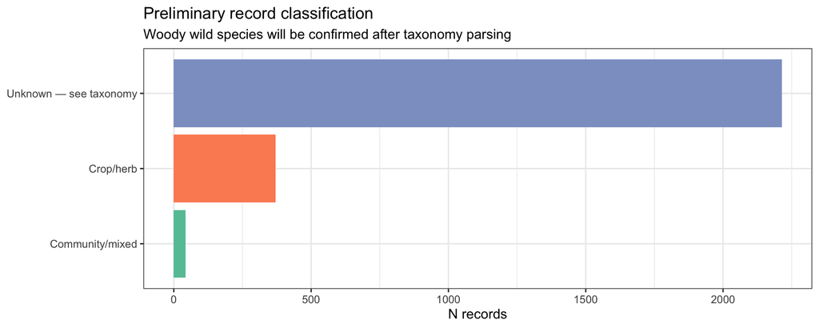

```r
type_counts <- nik_enq |>
  count(record_type_prelim, name = "n") |>
  mutate(record_type_prelim = reorder(record_type_prelim, n))

ggplot(type_counts, aes(record_type_prelim, n, fill = record_type_prelim)) +
  geom_col(show.legend = FALSE) +
  coord_flip() +
  scale_fill_brewer(palette = "Set2") +
  labs(title = "Preliminary record classification",
       subtitle = "Woody wild species will be confirmed after taxonomy parsing",
       x = NULL, y = "N records")
```

# 4 Taxonomy

```r
ne_genus_lookup <- tibble::tribble(
  ~genus,           ~ne_family,            ~ne_division,
  "Abies",          "Pinaceae",            "Gymnosperm",
  "Picea",          "Pinaceae",            "Gymnosperm",
  "Pinus",          "Pinaceae",            "Gymnosperm",
  "Pseudotsuga",    "Pinaceae",            "Gymnosperm",
  "Larix",          "Pinaceae",            "Gymnosperm",
  "Tsuga",          "Pinaceae",            "Gymnosperm",
  "Cedrus",         "Pinaceae",            "Gymnosperm",
  "Juniperus",      "Cupressaceae",        "Gymnosperm",
  "Thuja",          "Cupressaceae",        "Gymnosperm",
  "Chamaecyparis",  "Cupressaceae",        "Gymnosperm",
  "Cryptomeria",    "Cupressaceae",        "Gymnosperm",
  "Podocarpus",     "Podocarpaceae",       "Gymnosperm",
  "Araucaria",      "Araucariaceae",       "Gymnosperm",
  "Taxus",          "Taxaceae",            "Gymnosperm",
  "Ginkgo",         "Ginkgoaceae",         "Gymnosperm",
  "Sequoia",        "Cupressaceae",        "Gymnosperm",
  "Sequoiadendron", "Cupressaceae",        "Gymnosperm",
  "Metasequoia",    "Cupressaceae",        "Gymnosperm",
  "Cupressus",      "Cupressaceae",        "Gymnosperm",
  "Quercus",        "Fagaceae",            "Angiosperm",
  "Fagus",          "Fagaceae",            "Angiosperm",
  "Nothofagus",     "Nothofagaceae",       "Angiosperm",
  "Betula",         "Betulaceae",          "Angiosperm",
  "Alnus",          "Betulaceae",          "Angiosperm",
  "Populus",        "Salicaceae",          "Angiosperm",
  "Salix",          "Salicaceae",          "Angiosperm",
  "Eucalyptus",     "Myrtaceae",           "Angiosperm",
  "Acacia",         "Fabaceae",            "Angiosperm",
  "Robinia",        "Fabaceae",            "Angiosperm",
  "Tilia",          "Malvaceae",           "Angiosperm",
  "Fraxinus",       "Oleaceae",            "Angiosperm",
  "Acer",           "Sapindaceae",         "Angiosperm",
  "Juglans",        "Juglandaceae",        "Angiosperm",
  "Carya",          "Juglandaceae",        "Angiosperm",
  "Magnolia",       "Magnoliaceae",        "Angiosperm",
  "Shorea",         "Dipterocarpaceae",    "Angiosperm",
  "Rhizophora",     "Rhizophoraceae",      "Angiosperm",
  "Prunus",         "Rosaceae",            "Angiosperm",
  "Cornus",         "Cornaceae",           "Angiosperm",
  "Liriodendron",   "Magnoliaceae",        "Angiosperm",
  "Castanea",       "Fagaceae",            "Angiosperm",
  "Corylus",        "Betulaceae",          "Angiosperm",
  "Carpinus",       "Betulaceae",          "Angiosperm",
  "Ulmus",          "Ulmaceae",            "Angiosperm",
  "Celtis",         "Cannabaceae",         "Angiosperm",
  "Liquidambar",    "Altingiaceae",        "Angiosperm",
  "Platanus",       "Platanaceae",         "Angiosperm",
  "Nyssa",          "Nyssaceae",           "Angiosperm",
  "Betula",         "Betulaceae",          "Angiosperm",
  "Cinnamomum",     "Lauraceae",           "Angiosperm",
  "Swietenia",      "Meliaceae",           "Angiosperm",
  "Tectona",        "Lamiaceae",           "Angiosperm",
  "Dipterocarpus",  "Dipterocarpaceae",    "Angiosperm",
  "Hopea",          "Dipterocarpaceae",    "Angiosperm",
  "Cedrela",        "Meliaceae",           "Angiosperm",
  "Terminalia",     "Combretaceae",        "Angiosperm",
  "Virola",         "Myristicaceae",       "Angiosperm",
  "Heliocarpus",    "Malvaceae",           "Angiosperm"
) |> dplyr::distinct(genus, .keep_all = TRUE)
```

```r
ne_parse_taxa <- function(taxa_vec) {
  cleaned <- taxa_vec |>
    stringr::str_trim() |> stringr::str_squish() |>
    stringr::str_remove_all("\\s*\\([^)]*\\)") |>
    stringr::str_remove("\\s*\\[[^\\]]*\\]$") |>
    stringr::str_remove("\\s+(ssp\\.|subsp\\.|var\\.|f\\.|cv\\.)\\s+\\S+.*$") |>
    stringr::str_remove("(?i)\\s+sp+\\.?\\s*$") |>
    stringr::str_trim()
  genus_vec <- stringr::word(cleaned, 1)
  second_wd <- stringr::word(cleaned, 2)
  has_epi   <- !is.na(second_wd) &
    stringr::str_detect(second_wd, "^[a-z][a-z\\-]+$") &
    !second_wd %in% c("sp","spp","sp.","spp.")
  binomial <- dplyr::if_else(has_epi, paste(genus_vec, second_wd), NA_character_)
  flag_community <- stringr::str_detect(
    taxa_vec, stringr::regex("community|stand|mixed|plot|forest|woodland", ignore_case = TRUE))
  dplyr::tibble(
    taxa_orig      = taxa_vec,
    taxa_cleaned   = cleaned,
    binomial       = binomial,
    genus          = genus_vec,
    flag_sp_only   = !has_epi & !is.na(genus_vec),
    flag_community = flag_community,
    flag_uncertain = is.na(binomial) | flag_community
  )
}

ne_parsed <- ne_parse_taxa(nik_enq$taxa)

ne_annotated <- nik_enq |>
  bind_cols(ne_parsed |> select(-taxa_orig, -flag_community)) |>
  left_join(ne_genus_lookup, by = "genus") |>
  mutate(
    record_type = case_when(
      flag_crop      ~ "Crop/herb",
      flag_community ~ "Community/mixed",
      ne_division == "Gymnosperm" ~ "Gymnosperm",
      ne_division == "Angiosperm" ~ "Angiosperm",
      TRUE ~ "Unknown"
    )
  )

cat("Record type breakdown:\n")
```

```
## Record type breakdown:
```

```r
print(ne_annotated |> count(record_type, sort = TRUE))
```

```
## # A tibble: 5 × 2
##   record_type         n
##   <chr>           <int>
## 1 Unknown          1157
## 2 Gymnosperm        606
## 3 Angiosperm        451
## 4 Crop/herb         370
## 5 Community/mixed    42
```

```r
# Primary dataset: wild woody species only (exclude crops and community stands)
ne_wild <- ne_annotated |>
  dplyr::filter(!flag_crop, !flag_community)

# Species means: use records with valid binomial, known biomass > 0
ne_sp_means <- ne_wild |>
  dplyr::filter(!flag_uncertain, !is.na(binomial), total_biomass_kg > 0) |>
  dplyr::mutate(
    # Compute non-leaf at record level BEFORE log-transform (Jensen's inequality)
    nonleaf_kg  = dplyr::if_else(!is.na(leaf_biomass_kg) & leaf_biomass_kg > 0 &
                                   total_biomass_kg > leaf_biomass_kg,
                                 total_biomass_kg - leaf_biomass_kg, NA_real_),
    log10_total  = log10(total_biomass_kg),
    log10_stem   = log10(stem_biomass_kg),
    log10_leaf   = log10(leaf_biomass_kg),
    log10_root   = log10(root_biomass_kg),
    log10_shoot  = log10(shoot_biomass_kg),
    log10_repro  = log10(repro_biomass_kg),
    log10_height = log10(height_m),
    log10_nonleaf = log10(nonleaf_kg),
    log10_total_growth = log10(total_growth_kgyr),
    log10_stem_growth  = log10(stem_growth_kgyr),
    log10_leaf_growth  = log10(leaf_growth_kgyr),
    log10_root_growth  = log10(root_growth_kgyr)
  ) |>
  dplyr::mutate(across(starts_with("log10_"), ~ ifelse(is.nan(.) | is.infinite(.), NA_real_, .))) |>
  dplyr::group_by(binomial, ne_family, ne_division) |>
  dplyr::summarise(
    across(starts_with("log10_"), ~ mean(.x, na.rm = TRUE)),
    n_records = n(),
    .groups = "drop"
  ) |>
  dplyr::mutate(across(starts_with("log10_"), ~ ifelse(is.nan(.) | is.infinite(.), NA_real_, .))) |>
  dplyr::mutate(
    sp_tree = gsub(" ", "_", binomial)
  )

cat(sprintf("Species means: %d species, %d families\n",
            nrow(ne_sp_means), n_distinct(ne_sp_means$ne_family, na.rm = TRUE)))
```

```
## Species means: 77 species, 10 families
```

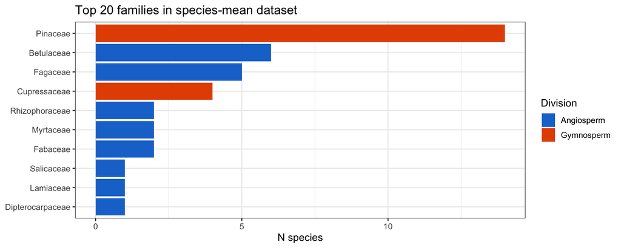

```r
ne_sp_means |>
  dplyr::filter(!is.na(ne_division)) |>
  dplyr::count(ne_family, ne_division) |>
  dplyr::arrange(desc(n)) |>
  dplyr::slice_head(n = 20) |>
  dplyr::mutate(ne_family = reorder(ne_family, n)) |>
  ggplot(aes(ne_family, n, fill = ne_division)) +
  geom_col() +
  coord_flip() +
  scale_fill_manual(values = c(Gymnosperm = "#E65100", Angiosperm = "#1976D2")) +
  labs(title = "Top 20 families in species-mean dataset",
       x = NULL, y = "N species", fill = "Division")
```

# 5 Phylogeny

```r
ne_phy_tree <- NULL

if (HAS_PHYLOMAKER && nrow(ne_sp_means) > 10) {
  sp_for_tree <- ne_sp_means |>
    dplyr::filter(!is.na(ne_family), !is.na(binomial)) |>
    dplyr::mutate(genus_col = stringr::word(binomial, 1)) |>
    dplyr::distinct(binomial, genus_col, ne_family) |>
    dplyr::rename(species = binomial, genus = genus_col, family = ne_family)

  ne_phy_tree <- tryCatch({
    res <- V.PhyloMaker2::phylo.maker(
      sp.list = data.frame(
        species = gsub(" ", "_", sp_for_tree$species),
        genus   = sp_for_tree$genus,
        family  = sp_for_tree$family),
      tree    = V.PhyloMaker2::GBOTB.extended.TPL,
      nodes   = V.PhyloMaker2::nodes.info.1.TPL,
      scenario = "S3")
    # V.PhyloMaker2 >= 0.1.0 returns res$scenario.3 (not res$phylo)
    tr_obj <- if (!is.null(res$scenario.3)) res$scenario.3
              else if (!is.null(res$phylo))  res$phylo
              else NULL
    if (!is.null(tr_obj)) {
      tr_obj$node.label <- NULL
      tr_obj
    } else NULL
  }, error = function(e) { message("V.PhyloMaker2 failed: ", e$message); NULL })

  if (!is.null(ne_phy_tree)) {
    n_matched <- sum(ne_sp_means$sp_tree %in% ne_phy_tree$tip.label)
    cat(sprintf("Phylogeny: %d tips; %d/%d species matched\n",
                length(ne_phy_tree$tip.label), n_matched, nrow(ne_sp_means)))
  }
} else {
  message("V.PhyloMaker2 not available — PGLS analyses will be skipped.")
}
```

```
## Phylogeny: 38 tips; 38/77 species matched
```

# 6 Phylogenetic Signal

```r
if (!is.null(ne_phy_tree)) {
  signal_vars <- c("log10_leaf", "log10_stem", "log10_root", "log10_shoot",
                   "log10_total", "log10_height", "log10_nonleaf")

  signal_results <- map_dfr(signal_vars, function(v) {
    sub <- ne_sp_means |>
      dplyr::filter(!is.na(.data[[v]]), sp_tree %in% ne_phy_tree$tip.label) |>
      dplyr::distinct(sp_tree, .keep_all = TRUE)
    if (nrow(sub) < 10) return(NULL)
    tr2 <- ape::keep.tip(ne_phy_tree, sub$sp_tree)
    x   <- setNames(sub[[v]], sub$sp_tree)
    lam <- tryCatch(phytools::phylosig(tr2, x, method = "lambda", test = TRUE),
                    error = function(e) NULL)
    Kst <- tryCatch(phytools::phylosig(tr2, x, method = "K", test = TRUE),
                    error = function(e) NULL)
    tibble(
      trait   = v,
      n       = nrow(sub),
      lambda  = if (!is.null(lam)) round(lam$lambda, 3) else NA_real_,
      lam_p   = if (!is.null(lam)) round(lam$P, 4)     else NA_real_,
      K       = if (!is.null(Kst)) round(Kst$K, 3)     else NA_real_,
      K_p     = if (!is.null(Kst)) round(Kst$P, 4)     else NA_real_
    )
  })

  kable(signal_results,
        caption = "Phylogenetic signal: Pagel's lambda and Blomberg's K for each organ trait.")
} else {
  message("Phylogeny not available — phylogenetic signal analysis skipped.")
}
```

Phylogenetic signal: Pagel’s lambda and Blomberg’s K for each organ trait.

| trait | n | lambda | lam_p | K | K_p |
| --- | --- | --- | --- | --- | --- |
| log10_leaf | 38 | 0 | 1 | 0.141 | 0.016 |
| log10_stem | 38 | 0 | 1 | 0.133 | 0.016 |
| log10_root | 38 | 0 | 1 | 0.124 | 0.027 |
| log10_shoot | 38 | 0 | 1 | 0.134 | 0.022 |
| log10_total | 38 | 0 | 1 | 0.132 | 0.013 |
| log10_height | 33 | 0 | 1 | 0.103 | 0.033 |
| log10_nonleaf | 38 | 0 | 1 | 0.128 | 0.027 |

# 7 run_one_allom Helper

```r
run_one_allom <- function(df, tree, y_col, x_col, rel_label,
                           wbe_slope = NA_real_, group_label = "All") {
  sub <- df |>
    dplyr::filter(is.finite(.data[[y_col]]), is.finite(.data[[x_col]]))
  if (!is.null(tree)) sub <- sub |> dplyr::filter(sp_tree %in% tree$tip.label)
  n <- nrow(sub)
  if (n < 8) {
    message(sprintf("Skipping %s ~ %s [%s] — n=%d", y_col, x_col, group_label, n))
    return(NULL)
  }

  ols_f  <- lm(as.formula(paste(y_col, "~", x_col)), data = sub)
  ols_s  <- summary(ols_f)
  ols_b  <- coef(ols_f)[2]
  ols_se <- coef(ols_s)[2, 2]
  ols_ci <- confint(ols_f)[2, ]
  ols_r2 <- ols_s$r.squared
  ols_p  <- if (!is.na(wbe_slope))
    2 * pt(abs((ols_b - wbe_slope) / ols_se), n - 2, lower.tail = FALSE) else NA_real_

  sma_f <- tryCatch(
    smatr::sma(as.formula(paste(y_col, "~", x_col)), data = sub),
    error = function(e) NULL)
  if (!is.null(sma_f)) {
    sma_b    <- sma_f$coef[[1]][2, 1]
    sma_cilo <- sma_f$coef[[1]][2, 2]
    sma_cihi <- sma_f$coef[[1]][2, 3]
    sma_r2   <- sma_f$r2[[1]]
    sma_p    <- if (!is.na(wbe_slope))
      tryCatch({
        st <- smatr::slope.test(sub[[y_col]], sub[[x_col]],
                                test.value = wbe_slope, method = "SMA")
        st$p
      }, error = function(e) NA_real_) else NA_real_
  } else {
    sma_b <- sma_cilo <- sma_cihi <- sma_r2 <- sma_p <- NA_real_
  }

  pgls_b <- pgls_se <- pgls_r2 <- pgls_lam <- pgls_p <-
    pgls_cilo <- pgls_cihi <- NA_real_
  if (!is.null(tree) && n >= 8) {
    tr2 <- ape::keep.tip(tree, sub$sp_tree)
    tr2$node.label <- NULL
    # Deduplicate by sp_tree before rowname assignment (prevents crash on duplicates)
    df_p <- as.data.frame(dplyr::distinct(sub, sp_tree, .keep_all = TRUE))
    rownames(df_p) <- df_p$sp_tree
    cd <- tryCatch(
      caper::comparative.data(phy = tr2, data = df_p, names.col = "sp_tree",
                               vcv = TRUE, warn.dropped = FALSE),
      error = function(e) NULL)
    if (!is.null(cd)) {
      pg_fixed_lambda <- FALSE
      pg <- tryCatch(
        caper::pgls(as.formula(paste(y_col, "~", x_col)),
                    data = cd, lambda = "ML", bounds = list(lambda = c(1e-6, 1))),
        error = function(e) {
          message(sprintf("PGLS ML failed [%s/%s]: %s — retrying lambda=1",
                          rel_label, group_label, e$message))
          pg_fixed_lambda <<- TRUE
          tryCatch(caper::pgls(as.formula(paste(y_col, "~", x_col)),
                               data = cd, lambda = 1),
                   error = function(e2) NULL)
        })
      if (!is.null(pg)) {
        pg_s    <- summary(pg)
        pg_df   <- tryCatch(pg_s$df[2], error = function(e) n - 2L)
        pgls_b  <- coef(pg)[2]
        pgls_se <- coef(pg_s)[2, 2]
        pgls_t  <- qt(0.975, df = pg_df)
        pgls_ci <- pgls_b + c(-1, 1) * pgls_t * pgls_se
        pgls_cilo <- pgls_ci[1]; pgls_cihi <- pgls_ci[2]
        pgls_r2  <- pg_s$r.squared
        pgls_lam <- tryCatch(pg$param["lambda"], error = function(e) NA_real_)
        pgls_p   <- if (!is.na(wbe_slope))
          2 * pt(abs((pgls_b - wbe_slope) / pgls_se), df = pg_df, lower.tail = FALSE)
        else NA_real_
      }
    }
  }

  tibble::tibble(
    relationship = rel_label, group = group_label,
    y_var = y_col, x_var = x_col,
    wbe_slope = wbe_slope, n_species = n,
    method     = c("OLS", "SMA", "PGLS"),
    slope      = c(ols_b,    sma_b,    pgls_b),
    slope_se   = c(ols_se,   NA_real_, pgls_se),
    ci_lower   = c(ols_ci[1], sma_cilo, pgls_cilo),
    ci_upper   = c(ols_ci[2], sma_cihi, pgls_cihi),
    r_squared  = c(ols_r2,   sma_r2,   pgls_r2),
    lambda_ml  = c(NA_real_, NA_real_, pgls_lam),
    p_vs_wbe   = c(ols_p,    sma_p,    pgls_p)
  )
}
```

# 8 Interspecific Scaling — All Relationships

This section evaluates WBE/Enquist predictions for organ mass, height, and whole-plant growth scaling. The key growth-rate relationship is tested as:

$$\frac{dM}{dt} \propto M^{3/4}$$

where `total_growth_kgyr` approximates the annual net biomass increment and `total_biomass_kg` is the whole-plant size metric. The predicted WBE/Enquist exponents in this dataset are:

- total biomass vs height: exponent $\beta = 8/3 \approx 2.67$,
- whole-plant growth rate vs total biomass: exponent $\beta = 3/4 = 0.75$,
- leaf mass vs total biomass: exponent $\beta = 3/4 = 0.75$.

Because the Niklas-Enquist dataset contains annual net increments rather than instantaneous metabolic fluxes, this is an approximate descriptive test of WBE growth scaling, not a direct test of instantaneous metabolic rates.

```r
# All organ relationships to analyze with their WBE priors
relationships <- list(
  # Organ ~ Total biomass
  list(y = "log10_leaf",  x = "log10_total",  label = "Leaf ~ Total",        wbe = WBE_LEAF_TOTAL),
  list(y = "log10_root",  x = "log10_total",  label = "Root ~ Total",        wbe = WBE_ROOT_TOTAL),
  list(y = "log10_stem",  x = "log10_total",  label = "Stem ~ Total",        wbe = WBE_STEM_TOTAL),
  list(y = "log10_shoot", x = "log10_total",  label = "Shoot ~ Total",       wbe = WBE_SHOOT_TOTAL),
  list(y = "log10_repro", x = "log10_total",  label = "Repro ~ Total",       wbe = NA_real_),
  # Organ ~ Organ
  list(y = "log10_leaf",  x = "log10_stem",   label = "Leaf ~ Stem (KEY)",   wbe = WBE_LEAF_STEM),
  list(y = "log10_leaf",  x = "log10_root",   label = "Leaf ~ Root",         wbe = WBE_LEAF_ROOT),
  list(y = "log10_root",  x = "log10_stem",   label = "Root ~ Stem",         wbe = WBE_ROOT_STEM),
  list(y = "log10_root",  x = "log10_shoot",  label = "Root ~ Shoot",        wbe = WBE_ROOT_SHOOT),
  list(y = "log10_leaf",  x = "log10_nonleaf",label = "Leaf ~ Non-leaf",     wbe = WBE_LEAF_TOTAL),
  # Height relationships
  list(y = "log10_total", x = "log10_height", label = "Total ~ Height",      wbe = WBE_TOTAL_H),
  list(y = "log10_stem",  x = "log10_height", label = "Stem ~ Height",       wbe = NA_real_),
  list(y = "log10_leaf",  x = "log10_height", label = "Leaf ~ Height",       wbe = NA_real_),
  # Growth
  list(y = "log10_total_growth", x = "log10_total", label = "TotalGrowth ~ Total", wbe = WBE_GROWTH),
  list(y = "log10_stem_growth",  x = "log10_stem",  label = "StemGrowth ~ Stem",   wbe = WBE_GROWTH),
  list(y = "log10_leaf_growth",  x = "log10_leaf",  label = "LeafGrowth ~ Leaf",   wbe = WBE_GROWTH),
  list(y = "log10_root_growth",  x = "log10_root",  label = "RootGrowth ~ Root",   wbe = WBE_GROWTH)
)
```

```r
inter_results <- map_dfr(relationships, function(r) {
  run_one_allom(
    df          = ne_sp_means,
    tree        = ne_phy_tree,
    y_col       = r$y,
    x_col       = r$x,
    rel_label   = r$label,
    wbe_slope   = r$wbe,
    group_label = "All"
  )
})

kable(inter_results |>
        dplyr::select(relationship, group, method, n_species, slope, ci_lower, ci_upper,
               r_squared, lambda_ml, p_vs_wbe) |>
        dplyr::mutate(across(where(is.numeric), ~ round(.x, 3))),
      caption = "Interspecific organ scaling: OLS, SMA, PGLS across all wild species.")
```

Interspecific organ scaling: OLS, SMA, PGLS across all wild species.

| relationship | group | method | n_species | slope | ci_lower | ci_upper | r_squared | lambda_ml | p_vs_wbe |
| --- | --- | --- | --- | --- | --- | --- | --- | --- | --- |
| Leaf ~ Total | All | OLS | 38 | 0.772 | 0.707 | 0.838 | 0.941 | NA | 0.496 |
| Leaf ~ Total | All | SMA | 38 | 0.796 | 0.733 | 0.864 | 0.941 | NA | 0.150 |
| Leaf ~ Total | All | PGLS | 38 | 0.922 | 0.658 | 1.186 | 0.942 | 0.872 | 0.155 |
| Root ~ Total | All | OLS | 38 | 0.952 | 0.919 | 0.984 | 0.990 | NA | 0.005 |
| Root ~ Total | All | SMA | 38 | 0.956 | 0.924 | 0.990 | 0.990 | NA | 0.012 |
| Root ~ Total | All | PGLS | 38 | 0.953 | 0.935 | 0.971 | 1.000 | 0.825 | 0.001 |
| Stem ~ Total | All | OLS | 38 | 1.091 | 1.074 | 1.108 | 0.998 | NA | 0.000 |
| Stem ~ Total | All | SMA | 38 | 1.092 | 1.075 | 1.109 | 0.998 | NA | 0.000 |
| Stem ~ Total | All | PGLS | 38 | 1.032 | 0.999 | 1.066 | 0.999 | 0.000 | 0.057 |
| Shoot ~ Total | All | OLS | 38 | 1.017 | 1.003 | 1.030 | 0.998 | NA | 0.018 |
| Shoot ~ Total | All | SMA | 38 | 1.017 | 1.004 | 1.031 | 0.998 | NA | 0.013 |
| Shoot ~ Total | All | PGLS | 38 | 1.014 | 1.003 | 1.025 | 1.000 | 0.000 | 0.025 |
| Repro ~ Total | All | OLS | 15 | 0.608 | 0.290 | 0.927 | 0.567 | NA | NA |
| Repro ~ Total | All | SMA | 15 | 0.808 | 0.550 | 1.187 | 0.567 | NA | NA |
| Repro ~ Total | All | PGLS | 15 | 0.453 | 0.149 | 0.758 | 0.745 | 1.000 | NA |
| Leaf ~ Stem (KEY) | All | OLS | 38 | 0.706 | 0.645 | 0.767 | 0.938 | NA | 0.154 |
| Leaf ~ Stem (KEY) | All | SMA | 38 | 0.729 | 0.670 | 0.793 | 0.938 | NA | 0.494 |
| Leaf ~ Stem (KEY) | All | PGLS | 38 | 0.839 | 0.538 | 1.140 | 0.911 | 0.460 | 0.482 |
| Leaf ~ Root | All | OLS | 38 | 0.803 | 0.728 | 0.877 | 0.930 | NA | 0.161 |
| Leaf ~ Root | All | SMA | 38 | 0.832 | 0.761 | 0.910 | 0.930 | NA | 0.024 |
| Leaf ~ Root | All | PGLS | 38 | 0.891 | 0.561 | 1.220 | 0.906 | 0.304 | 0.322 |
| Root ~ Stem | All | OLS | 38 | 0.867 | 0.827 | 0.908 | 0.981 | NA | 0.000 |
| Root ~ Stem | All | SMA | 38 | 0.876 | 0.836 | 0.917 | 0.981 | NA | 0.000 |
| Root ~ Stem | All | PGLS | 38 | 0.920 | 0.881 | 0.958 | 0.999 | 0.000 | 0.003 |
| Root ~ Shoot | All | OLS | 38 | 0.931 | 0.887 | 0.975 | 0.981 | NA | 0.003 |
| Root ~ Shoot | All | SMA | 38 | 0.940 | 0.897 | 0.985 | 0.981 | NA | 0.011 |
| Root ~ Shoot | All | PGLS | 38 | 0.937 | 0.910 | 0.965 | 0.999 | 0.000 | 0.002 |
| Leaf ~ Non-leaf | All | OLS | 38 | 0.741 | 0.678 | 0.804 | 0.941 | NA | 0.774 |
| Leaf ~ Non-leaf | All | SMA | 38 | 0.764 | 0.704 | 0.830 | 0.941 | NA | 0.650 |
| Leaf ~ Non-leaf | All | PGLS | 38 | 0.818 | 0.522 | 1.114 | 0.910 | 0.245 | 0.582 |
| Total ~ Height | All | OLS | 33 | 2.568 | 2.193 | 2.944 | 0.863 | NA | 0.597 |
| Total ~ Height | All | SMA | 33 | 2.765 | 2.415 | 3.166 | 0.863 | NA | 0.589 |
| Total ~ Height | All | PGLS | 33 | 2.474 | 0.750 | 4.198 | 0.731 | 0.000 | 0.785 |
| Stem ~ Height | All | OLS | 33 | 2.753 | 2.334 | 3.172 | 0.853 | NA | NA |
| Stem ~ Height | All | SMA | 33 | 2.981 | 2.591 | 3.428 | 0.853 | NA | NA |
| Stem ~ Height | All | PGLS | 33 | 2.525 | 0.689 | 4.361 | 0.714 | 0.000 | NA |
| Leaf ~ Height | All | OLS | 33 | 1.772 | 1.311 | 2.233 | 0.664 | NA | NA |
| Leaf ~ Height | All | SMA | 33 | 2.174 | 1.761 | 2.684 | 0.664 | NA | NA |
| Leaf ~ Height | All | PGLS | 33 | 1.733 | -0.280 | 3.746 | 0.495 | 0.000 | NA |
| TotalGrowth ~ Total | All | OLS | 21 | 0.701 | 0.580 | 0.821 | 0.887 | NA | 0.403 |
| TotalGrowth ~ Total | All | SMA | 21 | 0.744 | 0.634 | 0.874 | 0.887 | NA | 0.923 |
| TotalGrowth ~ Total | All | PGLS | 21 | 0.949 | 0.683 | 1.215 | 0.944 | 0.000 | 0.113 |
| StemGrowth ~ Stem | All | OLS | 31 | 0.701 | 0.600 | 0.802 | 0.874 | NA | 0.330 |
| StemGrowth ~ Stem | All | SMA | 31 | 0.750 | 0.656 | 0.858 | 0.874 | NA | 0.998 |
| StemGrowth ~ Stem | All | PGLS | 31 | 0.958 | 0.678 | 1.239 | 0.939 | 0.000 | 0.114 |
| LeafGrowth ~ Leaf | All | OLS | 32 | 0.805 | 0.672 | 0.937 | 0.836 | NA | 0.407 |
| LeafGrowth ~ Leaf | All | SMA | 32 | 0.880 | 0.757 | 1.022 | 0.836 | NA | 0.038 |
| LeafGrowth ~ Leaf | All | PGLS | 32 | 0.913 | 0.753 | 1.073 | 0.977 | 1.000 | 0.047 |
| RootGrowth ~ Root | All | OLS | 21 | 0.664 | 0.512 | 0.816 | 0.814 | NA | 0.252 |
| RootGrowth ~ Root | All | SMA | 21 | 0.736 | 0.599 | 0.904 | 0.814 | NA | 0.848 |
| RootGrowth ~ Root | All | PGLS | 21 | 0.895 | 0.635 | 1.155 | 0.940 | 0.000 | 0.212 |

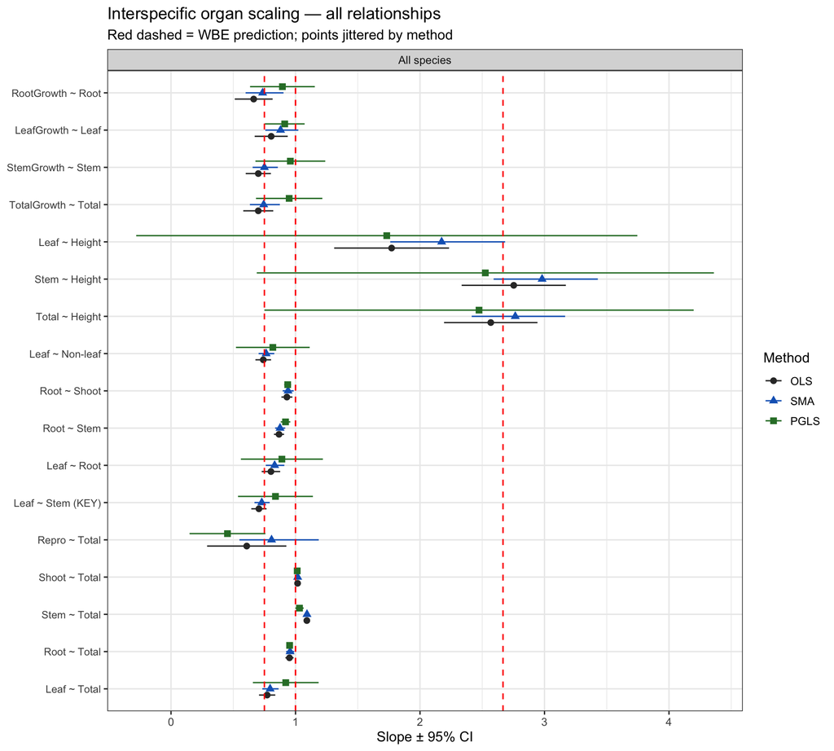

```r
inter_results |>
  dplyr::filter(!is.na(slope), is.finite(slope)) |>
  dplyr::mutate(
    relationship = factor(relationship, levels = unique(inter_results$relationship)),
    method = factor(method, levels = c("OLS", "SMA", "PGLS"))
  ) |>
  ggplot(aes(slope, relationship, colour = method, shape = method)) +
  geom_pointrange(aes(xmin = ci_lower, xmax = ci_upper),
                  position = position_dodge(width = 0.5), size = 0.5) +
  geom_vline(data = inter_results |>
               dplyr::filter(!is.na(wbe_slope)) |>
               dplyr::distinct(relationship, wbe_slope),
             aes(xintercept = wbe_slope), colour = "red",
             linetype = "dashed", linewidth = 0.6) +
  scale_colour_manual(values = c(OLS = "#333333", SMA = "#1565C0", PGLS = "#2E7D32")) +
  facet_wrap(~ "All species") +
  labs(title = "Interspecific organ scaling — all relationships",
       subtitle = "Red dashed = WBE prediction; points jittered by method",
       x = "Slope ± 95% CI", y = NULL, colour = "Method", shape = "Method") +
  theme(axis.text.y = element_text(size = 9))
```

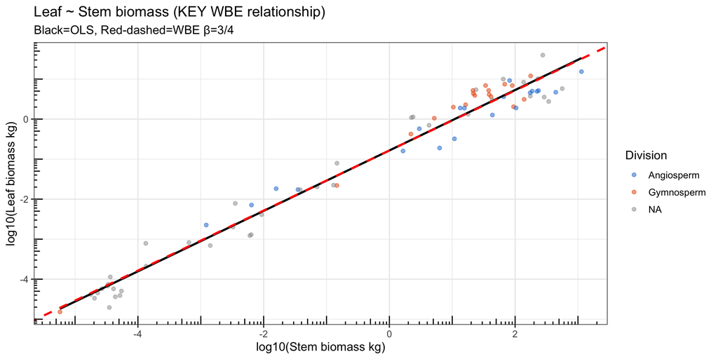

```r
ne_sp_means |>
  dplyr::filter(is.finite(log10_leaf), is.finite(log10_stem)) |>
  ggplot(aes(log10_stem, log10_leaf, colour = ne_division)) +
  geom_point(alpha = 0.5, size = 1.5) +
  geom_smooth(method = "lm", se = FALSE, aes(group = 1),
              colour = "black", linewidth = 1) +
  geom_abline(slope = WBE_LEAF_STEM,
              intercept = {
                sub <- ne_sp_means |> dplyr::filter(is.finite(log10_leaf), is.finite(log10_stem))
                mean(sub$log10_leaf, na.rm = TRUE) - WBE_LEAF_STEM * mean(sub$log10_stem, na.rm = TRUE)
              },
              colour = "red", linetype = "dashed", linewidth = 1) +
  annotation_logticks(sides = "bl") +
  scale_colour_manual(values = c(Gymnosperm = "#E65100", Angiosperm = "#1976D2"),
                      na.value = "grey60") +
  labs(title = "Leaf ~ Stem biomass (KEY WBE relationship)",
       subtitle = "Black=OLS, Red-dashed=WBE β=3/4",
       x = "log10(Stem biomass kg)", y = "log10(Leaf biomass kg)",
       colour = "Division")
```

# 9 Gymnosperm vs Angiosperm

```r
div_results <- map_dfr(c("Gymnosperm", "Angiosperm"), function(div) {
  sp_div <- ne_sp_means |> dplyr::filter(ne_division == div)
  map_dfr(relationships, function(r) {
    run_one_allom(
      df          = sp_div,
      tree        = ne_phy_tree,
      y_col       = r$y,
      x_col       = r$x,
      rel_label   = r$label,
      wbe_slope   = r$wbe,
      group_label = div
    )
  })
})

kable(div_results |>
        dplyr::select(relationship, group, method, n_species, slope, ci_lower, ci_upper,
               r_squared, p_vs_wbe) |>
        dplyr::mutate(across(where(is.numeric), ~ round(.x, 3))),
      caption = "Division-stratified organ scaling: Gymnosperm vs. Angiosperm.")
```

Division-stratified organ scaling: Gymnosperm vs. Angiosperm.

| relationship | group | method | n_species | slope | ci_lower | ci_upper | r_squared | p_vs_wbe |
| --- | --- | --- | --- | --- | --- | --- | --- | --- |
| Leaf ~ Total | Gymnosperm | OLS | 18 | 0.848 | 0.766 | 0.930 | 0.968 | 0.023 |
| Leaf ~ Total | Gymnosperm | SMA | 18 | 0.862 | 0.783 | 0.948 | 0.968 | 0.007 |
| Leaf ~ Total | Gymnosperm | PGLS | 18 | 1.028 | -0.498 | 2.555 | 0.987 | 0.259 |
| Root ~ Total | Gymnosperm | OLS | 18 | 0.991 | 0.955 | 1.026 | 0.995 | 0.579 |
| Root ~ Total | Gymnosperm | SMA | 18 | 0.993 | 0.958 | 1.029 | 0.995 | 0.673 |
| Root ~ Total | Gymnosperm | PGLS | 18 | 0.953 | 0.791 | 1.114 | 1.000 | 0.167 |
| Stem ~ Total | Gymnosperm | OLS | 18 | 1.073 | 1.057 | 1.089 | 0.999 | 0.000 |
| Stem ~ Total | Gymnosperm | SMA | 18 | 1.073 | 1.057 | 1.089 | 0.999 | 0.000 |
| Stem ~ Total | Gymnosperm | PGLS | 18 | 1.004 | 0.812 | 1.195 | 1.000 | 0.852 |
| Shoot ~ Total | Gymnosperm | OLS | 18 | 1.002 | 0.991 | 1.014 | 1.000 | 0.659 |
| Shoot ~ Total | Gymnosperm | SMA | 18 | 1.003 | 0.991 | 1.014 | 1.000 | 0.629 |
| Shoot ~ Total | Gymnosperm | PGLS | 18 | 1.013 | 0.966 | 1.059 | 1.000 | 0.180 |
| Repro ~ Total | Gymnosperm | OLS | 9 | 0.583 | 0.360 | 0.807 | 0.845 | NA |
| Repro ~ Total | Gymnosperm | SMA | 9 | 0.635 | 0.449 | 0.896 | 0.845 | NA |
| Repro ~ Total | Gymnosperm | PGLS | 9 | 0.541 | 0.458 | 0.625 | 1.000 | NA |
| Leaf ~ Stem (KEY) | Gymnosperm | OLS | 18 | 0.789 | 0.710 | 0.868 | 0.966 | 0.311 |
| Leaf ~ Stem (KEY) | Gymnosperm | SMA | 18 | 0.803 | 0.728 | 0.886 | 0.966 | 0.161 |
| Leaf ~ Stem (KEY) | Gymnosperm | PGLS | 18 | 1.023 | -0.693 | 2.739 | 0.983 | 0.293 |
| Leaf ~ Root | Gymnosperm | OLS | 18 | 0.849 | 0.753 | 0.945 | 0.956 | 0.045 |
| Leaf ~ Root | Gymnosperm | SMA | 18 | 0.868 | 0.777 | 0.969 | 0.956 | 0.013 |
| Leaf ~ Root | Gymnosperm | PGLS | 18 | 1.078 | -0.708 | 2.863 | 0.983 | 0.258 |
| Root ~ Stem | Gymnosperm | OLS | 18 | 0.922 | 0.881 | 0.963 | 0.993 | 0.001 |
| Root ~ Stem | Gymnosperm | SMA | 18 | 0.925 | 0.885 | 0.967 | 0.993 | 0.002 |
| Root ~ Stem | Gymnosperm | PGLS | 18 | 0.949 | 0.929 | 0.969 | 1.000 | 0.020 |
| Root ~ Shoot | Gymnosperm | OLS | 18 | 0.986 | 0.940 | 1.033 | 0.992 | 0.540 |
| Root ~ Shoot | Gymnosperm | SMA | 18 | 0.990 | 0.945 | 1.038 | 0.992 | 0.661 |
| Root ~ Shoot | Gymnosperm | PGLS | 18 | 0.941 | 0.738 | 1.144 | 1.000 | 0.168 |
| Leaf ~ Non-leaf | Gymnosperm | OLS | 18 | 0.810 | 0.727 | 0.892 | 0.964 | 0.144 |
| Leaf ~ Non-leaf | Gymnosperm | SMA | 18 | 0.825 | 0.746 | 0.911 | 0.964 | 0.061 |
| Leaf ~ Non-leaf | Gymnosperm | PGLS | 18 | 1.035 | -0.705 | 2.776 | 0.983 | 0.285 |

[output cut: 69 more lines]

```r
# ANCOVA slope homogeneity: test division × x_col interaction for key relationships
key_rels <- list(
  list(y = "log10_leaf",  x = "log10_stem",  label = "Leaf ~ Stem"),
  list(y = "log10_root",  x = "log10_shoot", label = "Root ~ Shoot"),
  list(y = "log10_stem",  x = "log10_total", label = "Stem ~ Total"),
  list(y = "log10_leaf",  x = "log10_total", label = "Leaf ~ Total")
)

ancova_results <- map_dfr(key_rels, function(r) {
  sub <- ne_sp_means |>
    dplyr::filter(
      is.finite(.data[[r$y]]), is.finite(.data[[r$x]]),
      ne_division %in% c("Gymnosperm", "Angiosperm")
    )
  if (nrow(sub) < 15) return(NULL)
  m_full <- lm(as.formula(paste(r$y, "~ ne_division *", r$x)), data = sub)
  m_para <- lm(as.formula(paste(r$y, "~ ne_division +", r$x)), data = sub)
  av <- anova(m_para, m_full)
  tibble(
    relationship     = r$label,
    n                = nrow(sub),
    interaction_F    = round(av$F[2], 3),
    interaction_p    = round(av$`Pr(>F)`[2], 4),
    slopes_homogeneous = av$`Pr(>F)`[2] > 0.05
  )
})

kable(ancova_results,
      caption = "ANCOVA test of slope homogeneity between Gymnosperm and Angiosperm.")
```

ANCOVA test of slope homogeneity between Gymnosperm and Angiosperm.

| relationship | n | interaction_F | interaction_p | slopes_homogeneous |
| --- | --- | --- | --- | --- |
| Leaf ~ Stem | 38 | 10.160 | 0.0031 | FALSE |
| Root ~ Shoot | 38 | 6.584 | 0.0149 | FALSE |
| Stem ~ Total | 38 | 5.096 | 0.0305 | FALSE |
| Leaf ~ Total | 38 | 7.726 | 0.0088 | FALSE |

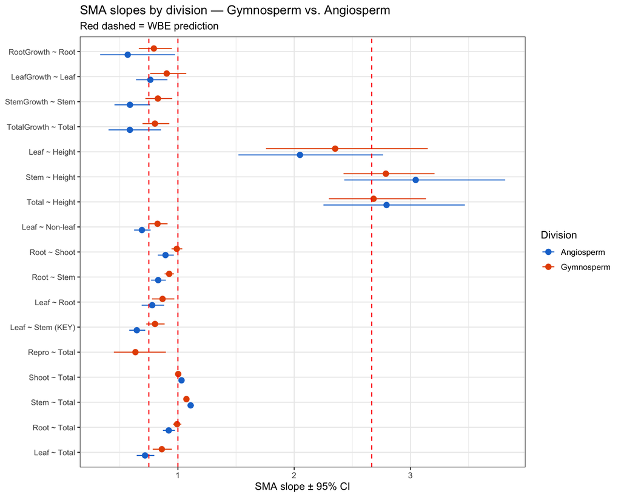

```r
div_results |>
  dplyr::filter(method == "SMA", !is.na(slope), is.finite(slope)) |>
  dplyr::mutate(relationship = factor(relationship, levels = unique(inter_results$relationship))) |>
  ggplot(aes(slope, relationship, colour = group)) +
  geom_pointrange(aes(xmin = ci_lower, xmax = ci_upper),
                  position = position_dodge(width = 0.5), size = 0.5) +
  geom_vline(data = div_results |>
               dplyr::filter(!is.na(wbe_slope)) |>
               dplyr::distinct(relationship, wbe_slope),
             aes(xintercept = wbe_slope), colour = "red",
             linetype = "dashed", linewidth = 0.6) +
  scale_colour_manual(values = c(Gymnosperm = "#E65100", Angiosperm = "#1976D2")) +
  labs(title = "SMA slopes by division — Gymnosperm vs. Angiosperm",
       subtitle = "Red dashed = WBE prediction",
       x = "SMA slope ± 95% CI", y = NULL, colour = "Division") +
  theme(axis.text.y = element_text(size = 9))
```

# 10 Family-Level Analysis

```r
# Families with ≥5 species in species-mean dataset
family_5sp <- ne_sp_means |>
  dplyr::filter(!is.na(ne_family)) |>
  dplyr::count(ne_family) |>
  dplyr::filter(n >= 5) |>
  dplyr::pull(ne_family)

cat(sprintf("Families with ≥5 species: %d\n", length(family_5sp)))
```

```
## Families with ≥5 species: 3
```

```r
key_rels_fam <- list(
  list(y = "log10_leaf",  x = "log10_stem",  label = "Leaf ~ Stem",  wbe = WBE_LEAF_STEM),
  list(y = "log10_root",  x = "log10_shoot", label = "Root ~ Shoot", wbe = WBE_ROOT_SHOOT),
  list(y = "log10_stem",  x = "log10_total", label = "Stem ~ Total", wbe = WBE_STEM_TOTAL),
  list(y = "log10_leaf",  x = "log10_total", label = "Leaf ~ Total", wbe = WBE_LEAF_TOTAL)
)

fam_results <- map_dfr(key_rels_fam, function(r) {
  map_dfr(family_5sp, function(fam) {
    sp_fam <- ne_sp_means |> dplyr::filter(ne_family == fam)
    # PGLS only if ≥10 species matched to tree
    use_tree <- if (!is.null(ne_phy_tree) &&
                    sum(sp_fam$sp_tree %in% ne_phy_tree$tip.label) >= 10)
      ne_phy_tree else NULL
    run_one_allom(
      df          = sp_fam,
      tree        = use_tree,
      y_col       = r$y,
      x_col       = r$x,
      rel_label   = r$label,
      wbe_slope   = r$wbe,
      group_label = fam
    )
  })
})

kable(fam_results |>
        dplyr::filter(method == "OLS") |>
        dplyr::select(relationship, group, n_species, slope, ci_lower, ci_upper,
               r_squared, p_vs_wbe) |>
        dplyr::mutate(across(where(is.numeric), ~ round(.x, 3))) |>
        dplyr::arrange(relationship, group),
      caption = "Family-level OLS slopes for key organ relationships (families ≥5 species).")
```

Family-level OLS slopes for key organ relationships (families ≥5 species).

| relationship | group | n_species | slope | ci_lower | ci_upper | r_squared | p_vs_wbe |
| --- | --- | --- | --- | --- | --- | --- | --- |
| Leaf ~ Stem | Pinaceae | 14 | 0.541 | 0.279 | 0.803 | 0.628 | 0.108 |
| Leaf ~ Total | Pinaceae | 14 | 0.586 | 0.295 | 0.876 | 0.616 | 0.242 |
| Root ~ Shoot | Pinaceae | 14 | 0.843 | 0.674 | 1.012 | 0.908 | 0.066 |
| Stem ~ Total | Pinaceae | 14 | 1.091 | 1.051 | 1.131 | 0.997 | 0.000 |

```r
# Cochran Q / I² heterogeneity across families for each key relationship
het_results <- map_dfr(key_rels_fam, function(r) {
  sub <- fam_results |>
    dplyr::filter(relationship == r$label, method == "OLS",
           !is.na(slope), !is.na(slope_se), slope_se > 0)
  if (nrow(sub) < 3) return(NULL)
  w  <- 1 / sub$slope_se^2
  wm <- weighted.mean(sub$slope, w)
  Q  <- sum(w * (sub$slope - wm)^2)
  df <- nrow(sub) - 1
  I2 <- max(0, (Q - df) / Q * 100)
  tibble(relationship = r$label, n_families = nrow(sub),
         Q = round(Q, 2), df = df,
         Q_p = round(pchisq(Q, df, lower.tail = FALSE), 4),
         I2_pct = round(I2, 1))
})

kable(het_results,
      caption = "Heterogeneity (I²) across families for key organ relationships.")
```

Table: Heterogeneity (I²) across families for key organ relationships.

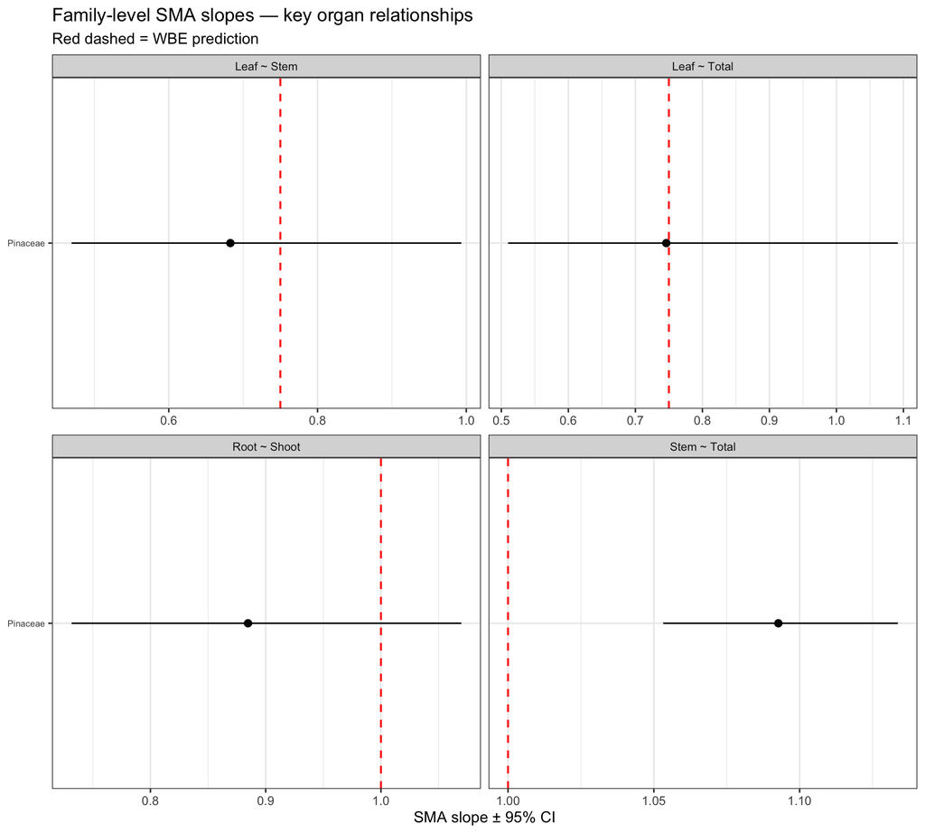

```r
fam_results |>
  dplyr::filter(method == "SMA", !is.na(slope), is.finite(slope)) |>
  dplyr::mutate(group = reorder(group, slope)) |>
  ggplot(aes(slope, group)) +
  geom_pointrange(aes(xmin = ci_lower, xmax = ci_upper), size = 0.4) +
  geom_vline(data = fam_results |>
               dplyr::filter(method == "SMA") |>
               dplyr::distinct(relationship, wbe_slope) |>
               dplyr::filter(!is.na(wbe_slope)),
             aes(xintercept = wbe_slope),
             colour = "red", linetype = "dashed", linewidth = 0.7,
             inherit.aes = FALSE) +
  facet_wrap(~ relationship, scales = "free_x", ncol = 2) +
  labs(title = "Family-level SMA slopes — key organ relationships",
       subtitle = "Red dashed = WBE prediction",
       x = "SMA slope ± 95% CI", y = NULL) +
  theme(axis.text.y = element_text(size = 7),
        strip.text = element_text(size = 9))
```

# 11 Intraspecific Scaling (Within NE Taxa)

```r
# Use raw ne_annotated before species-mean aggregation
# Wild species only, crop excluded
ne_wild_intra <- ne_annotated |>
  dplyr::filter(!flag_crop, !flag_community, !is.na(taxa))

# Count records per taxon (using parsed binomial where available, else taxa_cleaned)
intra_taxon_counts <- ne_wild_intra |>
  dplyr::mutate(intra_taxon = dplyr::if_else(!is.na(binomial), binomial, taxa_cleaned)) |>
  dplyr::count(intra_taxon, sort = TRUE) |>
  dplyr::filter(n >= 10)

cat(sprintf("Wild taxa with ≥10 NE records: %d\n", nrow(intra_taxon_counts)))
```

```
## Wild taxa with ≥10 NE records: 49
```

```r
kable(intra_taxon_counts |> head(20), caption = "Top 20 taxa by record count (intraspecific analysis).")
```

Top 20 taxa by record count (intraspecific analysis).

| intra_taxon | n |
| --- | --- |
| pearl millit | 360 |
| Cryptomeria japonica | 124 |
| Populus | 51 |
| Chamaecyparis obtusa | 50 |
| Dolicus | 50 |
| Pinus sylvestris | 46 |
| Soja max | 44 |
| Picea mariana | 40 |
| Betula pendula | 37 |
| Fagus sylvatica | 32 |
| Pinus banksiana | 29 |
| Picea abies | 28 |
| P. peltatum | 23 |
| Pinus rigida | 23 |
| Acacia mangium | 22 |
| Populus tremuloides | 22 |
| A. Sativa | 20 |
| Abies alba | 19 |
| Betula papyrifera | 18 |
| Oenothera biennis | 18 |

```r
intra_rels <- list(
  list(y = "log_leaf", x = "log_stem",   label = "Leaf ~ Stem",    wbe = WBE_LEAF_STEM),
  list(y = "log_root", x = "log_stem",   label = "Root ~ Stem",    wbe = WBE_ROOT_STEM),
  list(y = "log_root", x = "log_shoot",  label = "Root ~ Shoot",   wbe = WBE_ROOT_SHOOT),
  list(y = "log_total",x = "log_height", label = "Total ~ Height", wbe = WBE_TOTAL_H)
)

intra_results <- map_dfr(intra_taxon_counts$intra_taxon, function(tx) {
  sub_base <- ne_wild_intra |>
    dplyr::mutate(intra_taxon = dplyr::if_else(!is.na(binomial), binomial, taxa_cleaned)) |>
    dplyr::filter(intra_taxon == tx)

  map_dfr(intra_rels, function(r) {
    sub <- sub_base |>
      dplyr::filter(is.finite(.data[[r$y]]), is.finite(.data[[r$x]]))
    n <- nrow(sub)
    if (n < 8) return(NULL)

    x_range <- diff(range(sub[[r$x]], na.rm = TRUE))

    ols_f  <- tryCatch(lm(as.formula(paste(r$y, "~", r$x)), data = sub), error = function(e) NULL)
    sma_f  <- tryCatch(smatr::sma(as.formula(paste(r$y, "~", r$x)), data = sub), error = function(e) NULL)
    if (is.null(ols_f)) return(NULL)

    ols_s  <- summary(ols_f)
    ols_b  <- coef(ols_f)[2]
    ols_ci <- confint(ols_f)[2, ]
    ols_se <- coef(ols_s)[2, 2]

    sma_b    <- if (!is.null(sma_f)) sma_f$coef[[1]][2, 1] else NA_real_
    sma_cilo <- if (!is.null(sma_f)) sma_f$coef[[1]][2, 2] else NA_real_
    sma_cihi <- if (!is.null(sma_f)) sma_f$coef[[1]][2, 3] else NA_real_

    tibble(
      taxon       = tx,
      relationship = r$label,
      wbe_slope   = r$wbe,
      n           = n,
      x_log_range = round(x_range, 2),
      low_leverage = x_range < 1.0,   # flag if < 1 log10 decade
      ols_slope   = round(ols_b, 3),
      ols_ci_lo   = round(ols_ci[1], 3),
      ols_ci_hi   = round(ols_ci[2], 3),
      ols_r2      = round(ols_s$r.squared, 3),
      sma_slope   = round(sma_b, 3),
      sma_ci_lo   = round(sma_cilo, 3),
      sma_ci_hi   = round(sma_cihi, 3)
    )
  })
})

kable(intra_results |>
        dplyr::filter(relationship == "Leaf ~ Stem") |>
        dplyr::arrange(desc(n)) |>
        dplyr::select(taxon, n, x_log_range, low_leverage,
               ols_slope, ols_ci_lo, ols_ci_hi, ols_r2,
               sma_slope, sma_ci_lo, sma_ci_hi),
      caption = "Intraspecific Leaf ~ Stem scaling per taxon (n ≥ 8 records).")
```

Intraspecific Leaf ~ Stem scaling per taxon (n ≥ 8 records).

| taxon | n | x_log_range | low_leverage | ols_slope | ols_ci_lo | ols_ci_hi | ols_r2 | sma_slope | sma_ci_lo | sma_ci_hi |
| --- | --- | --- | --- | --- | --- | --- | --- | --- | --- | --- |
| Cryptomeria japonica | 96 | 3.55 | FALSE | 0.643 | 0.587 | 0.698 | 0.849 | 0.698 | 0.644 | 0.755 |
| Populus | 51 | 0.90 | TRUE | 0.510 | 0.399 | 0.622 | 0.633 | 0.641 | 0.539 | 0.762 |
| Chamaecyparis obtusa | 41 | 1.05 | FALSE | 0.562 | 0.453 | 0.672 | 0.735 | 0.656 | 0.556 | 0.775 |
| Betula pendula | 36 | 1.57 | FALSE | 0.287 | 0.179 | 0.394 | 0.462 | 0.421 | 0.327 | 0.542 |
| Pinus sylvestris | 28 | 1.64 | FALSE | 0.357 | 0.168 | 0.545 | 0.367 | 0.589 | 0.429 | 0.807 |
| P. peltatum | 23 | 1.85 | FALSE | 0.830 | 0.791 | 0.868 | 0.990 | 0.834 | 0.797 | 0.873 |
| Fagus sylvatica | 21 | 7.77 | FALSE | 0.715 | 0.690 | 0.740 | 0.995 | 0.717 | 0.692 | 0.742 |
| Abies alba | 19 | 3.06 | FALSE | 0.984 | 0.895 | 1.073 | 0.970 | 0.999 | 0.914 | 1.092 |
| Oenothera biennis | 18 | 1.37 | FALSE | -0.087 | -0.272 | 0.099 | 0.058 | -0.361 | -0.591 | -0.220 |
| Pinus nigra | 17 | 2.15 | FALSE | 0.675 | 0.572 | 0.778 | 0.928 | 0.700 | 0.605 | 0.811 |
| Vaccinium vilis-idaea | 17 | 0.54 | TRUE | 1.091 | 0.474 | 1.707 | 0.487 | 1.563 | 1.064 | 2.297 |
| Betula papyrifera | 16 | 0.49 | TRUE | 0.800 | 0.666 | 0.934 | 0.921 | 0.833 | 0.710 | 0.978 |
| Empetrum hemaphrodium | 16 | 0.52 | TRUE | 0.834 | 0.552 | 1.115 | 0.742 | 0.968 | 0.726 | 1.289 |
| Populus tremuloides | 15 | 5.16 | FALSE | 0.611 | 0.527 | 0.694 | 0.950 | 0.626 | 0.548 | 0.716 |
| Castanopsis cuspidata | 15 | 2.46 | FALSE | 0.636 | 0.544 | 0.727 | 0.945 | 0.654 | 0.568 | 0.752 |
| Vaccinium uliginosum | 15 | 0.69 | TRUE | 0.516 | 0.337 | 0.695 | 0.749 | 0.596 | 0.444 | 0.802 |
| Picea abies | 13 | 1.06 | FALSE | 0.766 | 0.476 | 1.056 | 0.754 | 0.882 | 0.638 | 1.219 |
| Abies veitchii | 13 | 5.44 | FALSE | 0.803 | 0.723 | 0.883 | 0.978 | 0.812 | 0.736 | 0.896 |
| Micranda spruceana, Eperua leucantha and about 130 other species. | 13 | 1.27 | FALSE | 0.687 | 0.472 | 0.901 | 0.818 | 0.759 | 0.574 | 1.004 |
| Pinus sylvestria | 13 | 2.54 | FALSE | 0.426 | 0.292 | 0.560 | 0.817 | 0.471 | 0.356 | 0.624 |
| Taraxiucm officinale | 12 | 2.67 | FALSE | 0.578 | 0.291 | 0.865 | 0.668 | 0.707 | 0.476 | 1.051 |
| Pinus banksiana, with some Picea mariana et al. | 12 | 0.55 | TRUE | 0.525 | 0.010 | 1.040 | 0.340 | 0.900 | 0.522 | 1.552 |
| Shorea robusta | 12 | 2.05 | FALSE | 0.552 | 0.426 | 0.678 | 0.905 | 0.580 | 0.467 | 0.720 |
| Hevea braziliensis | 11 | 3.05 | FALSE | 0.648 | 0.484 | 0.812 | 0.898 | 0.684 | 0.539 | 0.868 |
| Arran Comrade Potato | 11 | 1.93 | FALSE | 0.935 | 0.611 | 1.258 | 0.826 | 1.028 | 0.755 | 1.401 |
| aspen | 11 | 0.21 | TRUE | 0.430 | 0.157 | 0.703 | 0.585 | 0.562 | 0.352 | 0.897 |
| Abies firma | 10 | 1.54 | FALSE | 0.757 | 0.599 | 0.915 | 0.938 | 0.781 | 0.639 | 0.955 |

```r
kable(intra_results |>
        dplyr::arrange(relationship, taxon) |>
        dplyr::select(relationship, taxon, n, x_log_range, low_leverage,
               ols_slope, sma_slope, wbe_slope),
      caption = "All intraspecific relationships: OLS and SMA slopes per taxon.")
```

All intraspecific relationships: OLS and SMA slopes per taxon.

| relationship | taxon | n | x_log_range | low_leverage | ols_slope | sma_slope | wbe_slope |
| --- | --- | --- | --- | --- | --- | --- | --- |
| Leaf ~ Stem | Abies alba | 19 | 3.06 | FALSE | 0.984 | 0.999 | 0.750000 |
| Leaf ~ Stem | Abies firma | 10 | 1.54 | FALSE | 0.757 | 0.781 | 0.750000 |
| Leaf ~ Stem | Abies veitchii | 13 | 5.44 | FALSE | 0.803 | 0.812 | 0.750000 |
| Leaf ~ Stem | Arran Comrade Potato | 11 | 1.93 | FALSE | 0.935 | 1.028 | 0.750000 |
| Leaf ~ Stem | Betula papyrifera | 16 | 0.49 | TRUE | 0.800 | 0.833 | 0.750000 |
| Leaf ~ Stem | Betula pendula | 36 | 1.57 | FALSE | 0.287 | 0.421 | 0.750000 |
| Leaf ~ Stem | Castanopsis cuspidata | 15 | 2.46 | FALSE | 0.636 | 0.654 | 0.750000 |
| Leaf ~ Stem | Chamaecyparis obtusa | 41 | 1.05 | FALSE | 0.562 | 0.656 | 0.750000 |
| Leaf ~ Stem | Cryptomeria japonica | 96 | 3.55 | FALSE | 0.643 | 0.698 | 0.750000 |
| Leaf ~ Stem | Empetrum hemaphrodium | 16 | 0.52 | TRUE | 0.834 | 0.968 | 0.750000 |
| Leaf ~ Stem | Fagus sylvatica | 21 | 7.77 | FALSE | 0.715 | 0.717 | 0.750000 |
| Leaf ~ Stem | Hevea braziliensis | 11 | 3.05 | FALSE | 0.648 | 0.684 | 0.750000 |
| Leaf ~ Stem | Micranda spruceana, Eperua leucantha and about 130 other species. | 13 | 1.27 | FALSE | 0.687 | 0.759 | 0.750000 |
| Leaf ~ Stem | Oenothera biennis | 18 | 1.37 | FALSE | -0.087 | -0.361 | 0.750000 |
| Leaf ~ Stem | P. peltatum | 23 | 1.85 | FALSE | 0.830 | 0.834 | 0.750000 |
| Leaf ~ Stem | Picea abies | 13 | 1.06 | FALSE | 0.766 | 0.882 | 0.750000 |
| Leaf ~ Stem | Pinus banksiana, with some Picea mariana et al. | 12 | 0.55 | TRUE | 0.525 | 0.900 | 0.750000 |
| Leaf ~ Stem | Pinus nigra | 17 | 2.15 | FALSE | 0.675 | 0.700 | 0.750000 |
| Leaf ~ Stem | Pinus sylvestria | 13 | 2.54 | FALSE | 0.426 | 0.471 | 0.750000 |
| Leaf ~ Stem | Pinus sylvestris | 28 | 1.64 | FALSE | 0.357 | 0.589 | 0.750000 |
| Leaf ~ Stem | Populus | 51 | 0.90 | TRUE | 0.510 | 0.641 | 0.750000 |
| Leaf ~ Stem | Populus tremuloides | 15 | 5.16 | FALSE | 0.611 | 0.626 | 0.750000 |
| Leaf ~ Stem | Shorea robusta | 12 | 2.05 | FALSE | 0.552 | 0.580 | 0.750000 |
| Leaf ~ Stem | Taraxiucm officinale | 12 | 2.67 | FALSE | 0.578 | 0.707 | 0.750000 |
| Leaf ~ Stem | Vaccinium uliginosum | 15 | 0.69 | TRUE | 0.516 | 0.596 | 0.750000 |
| Leaf ~ Stem | Vaccinium vilis-idaea | 17 | 0.54 | TRUE | 1.091 | 1.563 | 0.750000 |
| Leaf ~ Stem | aspen | 11 | 0.21 | TRUE | 0.430 | 0.562 | 0.750000 |
| Root ~ Shoot | A. Sativa | 20 | 0.87 | TRUE | 0.719 | 0.828 | 1.000000 |
| Root ~ Shoot | Abies veitchii | 10 | 5.23 | FALSE | 0.974 | 0.974 | 1.000000 |
| Root ~ Shoot | Acacia mangium | 22 | 1.32 | FALSE | 0.918 | 0.938 | 1.000000 |

[output cut: 59 more lines]

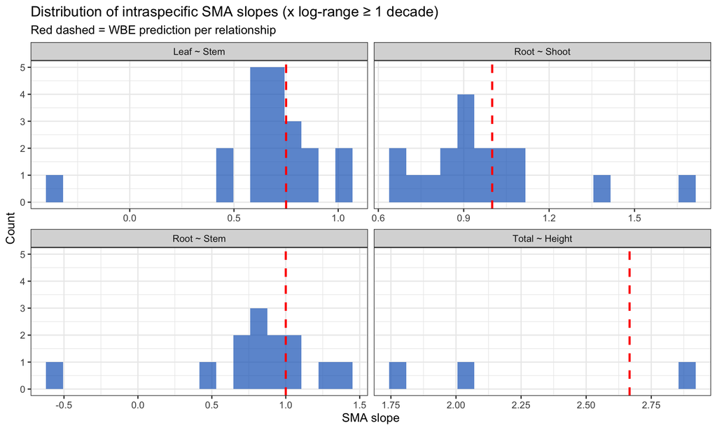

```r
intra_results |>
  dplyr::filter(!is.na(sma_slope), !low_leverage) |>
  ggplot(aes(sma_slope)) +
  geom_histogram(bins = 18, fill = "#1565C0", alpha = 0.7) +
  # Per-relationship WBE reference lines (avoids vline bleed across facets)
  geom_vline(data = intra_results |>
               dplyr::distinct(relationship, wbe_slope),
             aes(xintercept = wbe_slope),
             colour = "red", linetype = "dashed", linewidth = 1.0,
             inherit.aes = FALSE) +
  facet_wrap(~ relationship, scales = "free_x") +
  labs(title = "Distribution of intraspecific SMA slopes (x log-range ≥ 1 decade)",
       subtitle = "Red dashed = WBE prediction per relationship",
       x = "SMA slope", y = "Count")
```

```r
# Summary: mean intraspecific slope vs. interspecific
intra_summary <- intra_results |>
  dplyr::filter(!low_leverage) |>
  dplyr::group_by(relationship) |>
  dplyr::summarise(
    n_taxa          = n(),
    mean_ols        = round(mean(ols_slope, na.rm = TRUE), 3),
    sd_ols          = round(sd(ols_slope,   na.rm = TRUE), 3),
    mean_sma        = round(mean(sma_slope, na.rm = TRUE), 3),
    sd_sma          = round(sd(sma_slope,   na.rm = TRUE), 3),
    wbe_slope       = first(wbe_slope),
    .groups = "drop"
  )

inter_summary <- inter_results |>
  dplyr::filter(method %in% c("OLS","SMA"), group == "All") |>
  dplyr::group_by(relationship, method) |>
  dplyr::summarise(inter_slope = round(mean(slope, na.rm = TRUE), 3), .groups = "drop") |>
  tidyr::pivot_wider(names_from = method, values_from = inter_slope,
                     names_prefix = "inter_")

kable(dplyr::left_join(
    intra_summary,
    inter_summary |> dplyr::mutate(relationship = str_remove(relationship, " \\(KEY\\)")),
    by = "relationship"),
  caption = paste(
    "Intraspecific (mean ± SD across taxa) vs. interspecific slopes.",
    "Intraspecific rows exclude taxa with x log-range < 1 decade."))
```

Intraspecific (mean ± SD across taxa) vs. interspecific slopes. Intraspecific rows exclude taxa with x log-range < 1 decade.

| relationship | n_taxa | mean_ols | sd_ols | mean_sma | sd_sma | wbe_slope | inter_OLS | inter_SMA |
| --- | --- | --- | --- | --- | --- | --- | --- | --- |
| Leaf ~ Stem | 20 | 0.618 | 0.240 | 0.662 | 0.284 | 0.750000 | 0.706 | 0.729 |
| Root ~ Shoot | 18 | 0.924 | 0.254 | 0.969 | 0.244 | 1.000000 | 0.931 | 0.940 |
| Root ~ Stem | 13 | 0.765 | 0.420 | 0.803 | 0.472 | 1.000000 | 0.867 | 0.876 |
| Total ~ Height | 3 | 2.152 | 0.528 | 2.233 | 0.582 | 2.666667 | 2.568 | 2.765 |

# 12 WBE Scorecard

```r
scorecard <- bind_rows(
  inter_results |> dplyr::mutate(scale = "Interspecific"),
  div_results   |> dplyr::mutate(scale = paste("Div:", group))
) |>
  dplyr::filter(!is.na(wbe_slope), !is.na(slope), !is.na(ci_lower), !is.na(ci_upper)) |>
  dplyr::mutate(
    wbe_in_ci = wbe_slope >= ci_lower & wbe_slope <= ci_upper,
    support   = dplyr::case_when(
      wbe_in_ci & !is.na(p_vs_wbe) & p_vs_wbe > 0.05 ~ "Supported (β in CI, p>0.05)",
      wbe_in_ci                                        ~ "Marginal (β in CI, p≤0.05)",
      TRUE                                             ~ "Rejected (β outside CI)"
    )
  ) |>
  dplyr::select(scale, relationship, method, group, n_species, wbe_slope,
         slope, ci_lower, ci_upper, p_vs_wbe, wbe_in_ci, support) |>
  dplyr::mutate(across(c(slope, ci_lower, ci_upper, p_vs_wbe), ~ round(.x, 3)))

kable(scorecard |>
        dplyr::filter(scale == "Interspecific") |>
        dplyr::select(-scale),
      caption = "WBE scorecard: interspecific scaling. Is WBE β within 95% CI?")
```

WBE scorecard: interspecific scaling. Is WBE β within 95% CI?

| relationship | method | group | n_species | wbe_slope | slope | ci_lower | ci_upper | p_vs_wbe | wbe_in_ci | support |
| --- | --- | --- | --- | --- | --- | --- | --- | --- | --- | --- |
| Leaf ~ Total | OLS | All | 38 | 0.750000 | 0.772 | 0.707 | 0.838 | 0.496 | TRUE | Supported (β in CI, p>0.05) |
| Leaf ~ Total | SMA | All | 38 | 0.750000 | 0.796 | 0.733 | 0.864 | 0.150 | TRUE | Supported (β in CI, p>0.05) |
| Leaf ~ Total | PGLS | All | 38 | 0.750000 | 0.922 | 0.658 | 1.186 | 0.155 | TRUE | Supported (β in CI, p>0.05) |
| Root ~ Total | OLS | All | 38 | 1.000000 | 0.952 | 0.919 | 0.984 | 0.005 | FALSE | Rejected (β outside CI) |
| Root ~ Total | SMA | All | 38 | 1.000000 | 0.956 | 0.924 | 0.990 | 0.012 | FALSE | Rejected (β outside CI) |
| Root ~ Total | PGLS | All | 38 | 1.000000 | 0.953 | 0.935 | 0.971 | 0.001 | FALSE | Rejected (β outside CI) |
| Stem ~ Total | OLS | All | 38 | 1.000000 | 1.091 | 1.074 | 1.108 | 0.000 | FALSE | Rejected (β outside CI) |
| Stem ~ Total | SMA | All | 38 | 1.000000 | 1.092 | 1.075 | 1.109 | 0.000 | FALSE | Rejected (β outside CI) |
| Stem ~ Total | PGLS | All | 38 | 1.000000 | 1.032 | 0.999 | 1.066 | 0.057 | TRUE | Supported (β in CI, p>0.05) |
| Shoot ~ Total | OLS | All | 38 | 1.000000 | 1.017 | 1.003 | 1.030 | 0.018 | FALSE | Rejected (β outside CI) |
| Shoot ~ Total | SMA | All | 38 | 1.000000 | 1.017 | 1.004 | 1.031 | 0.013 | FALSE | Rejected (β outside CI) |
| Shoot ~ Total | PGLS | All | 38 | 1.000000 | 1.014 | 1.003 | 1.025 | 0.025 | FALSE | Rejected (β outside CI) |
| Leaf ~ Stem (KEY) | OLS | All | 38 | 0.750000 | 0.706 | 0.645 | 0.767 | 0.154 | TRUE | Supported (β in CI, p>0.05) |
| Leaf ~ Stem (KEY) | SMA | All | 38 | 0.750000 | 0.729 | 0.670 | 0.793 | 0.494 | TRUE | Supported (β in CI, p>0.05) |
| Leaf ~ Stem (KEY) | PGLS | All | 38 | 0.750000 | 0.839 | 0.538 | 1.140 | 0.482 | TRUE | Supported (β in CI, p>0.05) |
| Leaf ~ Root | OLS | All | 38 | 0.750000 | 0.803 | 0.728 | 0.877 | 0.161 | TRUE | Supported (β in CI, p>0.05) |
| Leaf ~ Root | SMA | All | 38 | 0.750000 | 0.832 | 0.761 | 0.910 | 0.024 | FALSE | Rejected (β outside CI) |
| Leaf ~ Root | PGLS | All | 38 | 0.750000 | 0.891 | 0.561 | 1.220 | 0.322 | TRUE | Supported (β in CI, p>0.05) |
| Root ~ Stem | OLS | All | 38 | 1.000000 | 0.867 | 0.827 | 0.908 | 0.000 | FALSE | Rejected (β outside CI) |
| Root ~ Stem | SMA | All | 38 | 1.000000 | 0.876 | 0.836 | 0.917 | 0.000 | FALSE | Rejected (β outside CI) |
| Root ~ Stem | PGLS | All | 38 | 1.000000 | 0.920 | 0.881 | 0.958 | 0.003 | FALSE | Rejected (β outside CI) |
| Root ~ Shoot | OLS | All | 38 | 1.000000 | 0.931 | 0.887 | 0.975 | 0.003 | FALSE | Rejected (β outside CI) |
| Root ~ Shoot | SMA | All | 38 | 1.000000 | 0.940 | 0.897 | 0.985 | 0.011 | FALSE | Rejected (β outside CI) |
| Root ~ Shoot | PGLS | All | 38 | 1.000000 | 0.937 | 0.910 | 0.965 | 0.002 | FALSE | Rejected (β outside CI) |
| Leaf ~ Non-leaf | OLS | All | 38 | 0.750000 | 0.741 | 0.678 | 0.804 | 0.774 | TRUE | Supported (β in CI, p>0.05) |
| Leaf ~ Non-leaf | SMA | All | 38 | 0.750000 | 0.764 | 0.704 | 0.830 | 0.650 | TRUE | Supported (β in CI, p>0.05) |
| Leaf ~ Non-leaf | PGLS | All | 38 | 0.750000 | 0.818 | 0.522 | 1.114 | 0.582 | TRUE | Supported (β in CI, p>0.05) |
| Total ~ Height | OLS | All | 33 | 2.666667 | 2.568 | 2.193 | 2.944 | 0.597 | TRUE | Supported (β in CI, p>0.05) |
| Total ~ Height | SMA | All | 33 | 2.666667 | 2.765 | 2.415 | 3.166 | 0.589 | TRUE | Supported (β in CI, p>0.05) |
| Total ~ Height | PGLS | All | 33 | 2.666667 | 2.474 | 0.750 | 4.198 | 0.785 | TRUE | Supported (β in CI, p>0.05) |
| TotalGrowth ~ Total | OLS | All | 21 | 0.750000 | 0.701 | 0.580 | 0.821 | 0.403 | TRUE | Supported (β in CI, p>0.05) |
| TotalGrowth ~ Total | SMA | All | 21 | 0.750000 | 0.744 | 0.634 | 0.874 | 0.923 | TRUE | Supported (β in CI, p>0.05) |
| TotalGrowth ~ Total | PGLS | All | 21 | 0.750000 | 0.949 | 0.683 | 1.215 | 0.113 | TRUE | Supported (β in CI, p>0.05) |
| StemGrowth ~ Stem | OLS | All | 31 | 0.750000 | 0.701 | 0.600 | 0.802 | 0.330 | TRUE | Supported (β in CI, p>0.05) |
| StemGrowth ~ Stem | SMA | All | 31 | 0.750000 | 0.750 | 0.656 | 0.858 | 0.998 | TRUE | Supported (β in CI, p>0.05) |
| StemGrowth ~ Stem | PGLS | All | 31 | 0.750000 | 0.958 | 0.678 | 1.239 | 0.114 | TRUE | Supported (β in CI, p>0.05) |
| LeafGrowth ~ Leaf | OLS | All | 32 | 0.750000 | 0.805 | 0.672 | 0.937 | 0.407 | TRUE | Supported (β in CI, p>0.05) |
| LeafGrowth ~ Leaf | SMA | All | 32 | 0.750000 | 0.880 | 0.757 | 1.022 | 0.038 | FALSE | Rejected (β outside CI) |
| LeafGrowth ~ Leaf | PGLS | All | 32 | 0.750000 | 0.913 | 0.753 | 1.073 | 0.047 | FALSE | Rejected (β outside CI) |
| RootGrowth ~ Root | OLS | All | 21 | 0.750000 | 0.664 | 0.512 | 0.816 | 0.252 | TRUE | Supported (β in CI, p>0.05) |
| RootGrowth ~ Root | SMA | All | 21 | 0.750000 | 0.736 | 0.599 | 0.904 | 0.848 | TRUE | Supported (β in CI, p>0.05) |
| RootGrowth ~ Root | PGLS | All | 21 | 0.750000 | 0.895 | 0.635 | 1.155 | 0.212 | TRUE | Supported (β in CI, p>0.05) |

```r
kable(scorecard |>
        dplyr::filter(str_starts(scale, "Div")) |>
        dplyr::select(-scale),
      caption = "WBE scorecard: division-stratified analyses.")
```

WBE scorecard: division-stratified analyses.

| relationship | method | group | n_species | wbe_slope | slope | ci_lower | ci_upper | p_vs_wbe | wbe_in_ci | support |
| --- | --- | --- | --- | --- | --- | --- | --- | --- | --- | --- |
| Leaf ~ Total | OLS | Gymnosperm | 18 | 0.750000 | 0.848 | 0.766 | 0.930 | 0.023 | FALSE | Rejected (β outside CI) |
| Leaf ~ Total | SMA | Gymnosperm | 18 | 0.750000 | 0.862 | 0.783 | 0.948 | 0.007 | FALSE | Rejected (β outside CI) |
| Leaf ~ Total | PGLS | Gymnosperm | 18 | 0.750000 | 1.028 | -0.498 | 2.555 | 0.259 | TRUE | Supported (β in CI, p>0.05) |
| Root ~ Total | OLS | Gymnosperm | 18 | 1.000000 | 0.991 | 0.955 | 1.026 | 0.579 | TRUE | Supported (β in CI, p>0.05) |
| Root ~ Total | SMA | Gymnosperm | 18 | 1.000000 | 0.993 | 0.958 | 1.029 | 0.673 | TRUE | Supported (β in CI, p>0.05) |
| Root ~ Total | PGLS | Gymnosperm | 18 | 1.000000 | 0.953 | 0.791 | 1.114 | 0.167 | TRUE | Supported (β in CI, p>0.05) |
| Stem ~ Total | OLS | Gymnosperm | 18 | 1.000000 | 1.073 | 1.057 | 1.089 | 0.000 | FALSE | Rejected (β outside CI) |
| Stem ~ Total | SMA | Gymnosperm | 18 | 1.000000 | 1.073 | 1.057 | 1.089 | 0.000 | FALSE | Rejected (β outside CI) |
| Stem ~ Total | PGLS | Gymnosperm | 18 | 1.000000 | 1.004 | 0.812 | 1.195 | 0.852 | TRUE | Supported (β in CI, p>0.05) |
| Shoot ~ Total | OLS | Gymnosperm | 18 | 1.000000 | 1.002 | 0.991 | 1.014 | 0.659 | TRUE | Supported (β in CI, p>0.05) |
| Shoot ~ Total | SMA | Gymnosperm | 18 | 1.000000 | 1.003 | 0.991 | 1.014 | 0.629 | TRUE | Supported (β in CI, p>0.05) |
| Shoot ~ Total | PGLS | Gymnosperm | 18 | 1.000000 | 1.013 | 0.966 | 1.059 | 0.180 | TRUE | Supported (β in CI, p>0.05) |
| Leaf ~ Stem (KEY) | OLS | Gymnosperm | 18 | 0.750000 | 0.789 | 0.710 | 0.868 | 0.311 | TRUE | Supported (β in CI, p>0.05) |
| Leaf ~ Stem (KEY) | SMA | Gymnosperm | 18 | 0.750000 | 0.803 | 0.728 | 0.886 | 0.161 | TRUE | Supported (β in CI, p>0.05) |
| Leaf ~ Stem (KEY) | PGLS | Gymnosperm | 18 | 0.750000 | 1.023 | -0.693 | 2.739 | 0.293 | TRUE | Supported (β in CI, p>0.05) |
| Leaf ~ Root | OLS | Gymnosperm | 18 | 0.750000 | 0.849 | 0.753 | 0.945 | 0.045 | FALSE | Rejected (β outside CI) |
| Leaf ~ Root | SMA | Gymnosperm | 18 | 0.750000 | 0.868 | 0.777 | 0.969 | 0.013 | FALSE | Rejected (β outside CI) |
| Leaf ~ Root | PGLS | Gymnosperm | 18 | 0.750000 | 1.078 | -0.708 | 2.863 | 0.258 | TRUE | Supported (β in CI, p>0.05) |
| Root ~ Stem | OLS | Gymnosperm | 18 | 1.000000 | 0.922 | 0.881 | 0.963 | 0.001 | FALSE | Rejected (β outside CI) |
| Root ~ Stem | SMA | Gymnosperm | 18 | 1.000000 | 0.925 | 0.885 | 0.967 | 0.002 | FALSE | Rejected (β outside CI) |
| Root ~ Stem | PGLS | Gymnosperm | 18 | 1.000000 | 0.949 | 0.929 | 0.969 | 0.020 | FALSE | Rejected (β outside CI) |
| Root ~ Shoot | OLS | Gymnosperm | 18 | 1.000000 | 0.986 | 0.940 | 1.033 | 0.540 | TRUE | Supported (β in CI, p>0.05) |
| Root ~ Shoot | SMA | Gymnosperm | 18 | 1.000000 | 0.990 | 0.945 | 1.038 | 0.661 | TRUE | Supported (β in CI, p>0.05) |
| Root ~ Shoot | PGLS | Gymnosperm | 18 | 1.000000 | 0.941 | 0.738 | 1.144 | 0.168 | TRUE | Supported (β in CI, p>0.05) |
| Leaf ~ Non-leaf | OLS | Gymnosperm | 18 | 0.750000 | 0.810 | 0.727 | 0.892 | 0.144 | TRUE | Supported (β in CI, p>0.05) |
| Leaf ~ Non-leaf | SMA | Gymnosperm | 18 | 0.750000 | 0.825 | 0.746 | 0.911 | 0.061 | TRUE | Supported (β in CI, p>0.05) |
| Leaf ~ Non-leaf | PGLS | Gymnosperm | 18 | 0.750000 | 1.035 | -0.705 | 2.776 | 0.285 | TRUE | Supported (β in CI, p>0.05) |
| Total ~ Height | OLS | Gymnosperm | 16 | 2.666667 | 2.582 | 2.165 | 3.000 | 0.671 | TRUE | Supported (β in CI, p>0.05) |
| Total ~ Height | SMA | Gymnosperm | 16 | 2.666667 | 2.683 | 2.298 | 3.133 | 0.934 | TRUE | Supported (β in CI, p>0.05) |
| Total ~ Height | PGLS | Gymnosperm | 16 | 2.666667 | 2.887 | 1.966 | 3.808 | 0.202 | TRUE | Supported (β in CI, p>0.05) |

[output cut: 54 more lines]

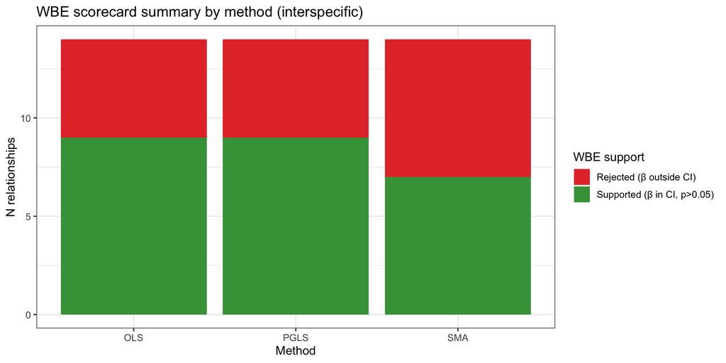

```r
scorecard |>
  dplyr::filter(scale == "Interspecific") |>
  dplyr::count(method, support) |>
  ggplot(aes(method, n, fill = support)) +
  geom_col(position = "stack") +
  scale_fill_manual(values = c(
    "Supported (β in CI, p>0.05)"  = "#43A047",
    "Marginal (β in CI, p≤0.05)"  = "#FFA726",
    "Rejected (β outside CI)"      = "#E53935")) +
  labs(title = "WBE scorecard summary by method (interspecific)",
       x = "Method", y = "N relationships", fill = "WBE support")
```

# 13 Sensitivity: Including Crops

```r
# Species means including crop records
ne_sp_all <- ne_annotated |>
  dplyr::filter(!flag_community, !is.na(binomial), total_biomass_kg > 0) |>
  dplyr::mutate(
    # Compute non-leaf at record level BEFORE log-transform (avoids Jensen's inequality bias)
    nonleaf_kg  = dplyr::if_else(!is.na(leaf_biomass_kg) & leaf_biomass_kg > 0 &
                                   total_biomass_kg > leaf_biomass_kg,
                                 total_biomass_kg - leaf_biomass_kg, NA_real_),
    log10_total    = log10(total_biomass_kg),
    log10_stem     = log10(stem_biomass_kg),
    log10_leaf     = log10(leaf_biomass_kg),
    log10_root     = log10(root_biomass_kg),
    log10_shoot    = log10(shoot_biomass_kg),
    log10_repro    = log10(repro_biomass_kg),
    log10_height   = log10(height_m),
    log10_nonleaf  = log10(nonleaf_kg),
    log10_total_growth = log10(total_growth_kgyr),
    log10_stem_growth  = log10(stem_growth_kgyr),
    log10_leaf_growth  = log10(leaf_growth_kgyr),
    log10_root_growth  = log10(root_growth_kgyr)
  ) |>
  dplyr::mutate(across(starts_with("log10_"), ~ ifelse(is.nan(.) | is.infinite(.), NA_real_, .))) |>
  dplyr::group_by(binomial) |>
  dplyr::summarise(
    across(starts_with("log10_"), ~ mean(.x, na.rm = TRUE)),
    n_records = n(),
    .groups = "drop"
  ) |>
  dplyr::mutate(
    across(starts_with("log10_"), ~ ifelse(is.nan(.) | is.infinite(.), NA_real_, .)),
    sp_tree = gsub(" ", "_", binomial)
  )

# Key relationships only for sensitivity
sens_rels <- list(
  list(y = "log10_leaf", x = "log10_stem",  label = "Leaf ~ Stem",  wbe = WBE_LEAF_STEM),
  list(y = "log10_leaf", x = "log10_total", label = "Leaf ~ Total", wbe = WBE_LEAF_TOTAL),
  list(y = "log10_root", x = "log10_shoot", label = "Root ~ Shoot", wbe = WBE_ROOT_SHOOT)
)

sens_results <- map_dfr(sens_rels, function(r) {
  run_one_allom(
    df          = ne_sp_all,
    tree        = NULL,   # no tree needed for sensitivity comparison
    y_col       = r$y,
    x_col       = r$x,
    rel_label   = r$label,
    wbe_slope   = r$wbe,
    group_label = "Including crops"
  )
})

# Compare wild-only vs. with-crops
sens_compare <- bind_rows(
  inter_results |>
    dplyr::filter(relationship %in% unique(sens_results$relationship), method %in% c("OLS","SMA")) |>
    dplyr::mutate(dataset = "Wild only"),
  sens_results |>
    dplyr::filter(method %in% c("OLS","SMA")) |>
    dplyr::mutate(dataset = "Including crops")
)

kable(sens_compare |>
        dplyr::select(relationship, dataset, method, n_species, slope, ci_lower, ci_upper, p_vs_wbe) |>
        dplyr::mutate(across(where(is.numeric), ~ round(.x, 3))),
      caption = "Sensitivity: WBE scorecard with vs. without crop species.")
```

Sensitivity: WBE scorecard with vs. without crop species.

[output not shown]

# 14 Bayesian PGLMM: Individual-Level Scaling

## 14.1 Motivation and Design

The OLS, SMA, and PGLS analyses above operate on **species means** — one data point per species. A Bayesian Phylogenetic Generalised Linear Mixed Model (PGLMM) operates instead on **individual-level observations**, partitioning variance explicitly into three components:

- $\sigma^2_{phy}$: variance among species attributable to shared evolutionary history (phylogenetic signal)
- $\sigma^2_{spp}$: non-phylogenetic species-level variance (ecological/developmental differences not explained by phylogeny)
- $\sigma^2_e$: individual-level residual (within-species variation and measurement error)

### 14.1.1 The Mundlak Device

Because the NE database contains 1–40+ observations per species spanning seedlings to old-growth trees, a naive individual-level regression would estimate a mixture of *inter-* and *intraspecific* slopes. We apply the **Mundlak (1978) within-between decomposition**:

$$\log_{10}(R_{ij}) = \alpha +
\underbrace{\beta_B
\,\overline{\log_{10}(M)}_i}_{\text{between-species}} +
\underbrace{\beta_W (\log_{10}(M_{ij}) -
\overline{\log_{10}(M)}_i)}_{\text{within-species}} + u_i^{phy} +
u_i^{spp} + \varepsilon_{ij}$$

where $i$ indexes species and $j$ indexes individual observations within a species. The **between-species slope $\beta_B$** is the PGLMM quantity comparable to the PGLS interspecific slope. The **within-species slope $\beta_W$** is comparable to intraspecific OLS regressions.

The phylogenetic random effect $u_i^{phy} \sim \mathcal{N}(\mathbf{0}, \sigma^2_{phy} \mathbf{C})$, where $\mathbf{C}$ is the Brownian-motion phylogenetic correlation matrix from `ape::vcv.phylo(tree, corr = TRUE)`. Implementation uses `brms` (Bürkner 2017) with Stan.

### 14.1.2 Caveats

- **$\beta_B$ is not identical to the PGLS slope**; it is a hierarchical Bayesian estimand from individual records. They are comparable estimators of the same theoretical quantity under shared assumptions.
- **Unbalanced sampling creates implicit weighting**: species with many records dominate estimation of $\sigma^2_e$ and $\beta_W$; singletons contribute only to $\beta_B$.
- **PGLMM is presented as a robustness and variance-decomposition supplement** to PGLS, not a replacement.
- Priors are weakly informative: $\beta_B, \beta_W \sim \mathcal{N}(1, 1)$; SD terms $\sim \text{Student-}t(3, 0, 0.5)$.
- Convergence assessed by $\hat{R} < 1.05$ and ESS ratio $> 0.1$ for all parameters.

```r
HAS_BRMS <- requireNamespace("brms", quietly = TRUE) &&
  utils::packageVersion("brms") >= "2.17.0"
if (!HAS_BRMS) message("brms ≥ 2.17.0 not available — PGLMM section will be skipped.")
```

```r
ne_wild_log10 <- ne_wild |>
  dplyr::filter(!is.na(binomial), !flag_uncertain) |>
  dplyr::mutate(
    log10_leaf  = log10(leaf_biomass_kg),
    log10_stem  = log10(stem_biomass_kg),
    log10_root  = log10(root_biomass_kg),
    log10_shoot = log10(shoot_biomass_kg),
    log10_total = log10(total_biomass_kg),
    log10_total_growth = log10(total_growth_kgyr),
    sp_tree     = gsub(" ", "_", binomial)
  ) |>
  dplyr::mutate(across(starts_with("log10_"), ~ ifelse(is.nan(.) | is.infinite(.), NA_real_, .)))

# Report records/species per division
ne_wild_log10 |>
  dplyr::filter(!is.na(ne_division)) |>
  dplyr::count(ne_division, name = "n_obs") |>
  dplyr::left_join(
    ne_wild_log10 |> dplyr::filter(!is.na(ne_division)) |>
      dplyr::group_by(ne_division) |>
      dplyr::summarise(n_spp = dplyr::n_distinct(sp_tree), .groups="drop"),
    by = "ne_division") |>
  kable(caption = "Individual-level records available for PGLMM by division.")
```

Individual-level records available for PGLMM by division.

| ne_division | n_obs | n_spp |
| --- | --- | --- |
| Angiosperm | 321 | 61 |
| Gymnosperm | 563 | 39 |

```r
# Species sampling summary (to assess Mundlak device validity)
samp_summary <- ne_wild_log10 |>
  dplyr::filter(!is.na(binomial)) |>
  dplyr::count(sp_tree, name = "n_records") |>
  dplyr::summarise(
    n_singletons = sum(n_records == 1),
    n_2_to_5     = sum(n_records >= 2 & n_records <= 5),
    n_6plus      = sum(n_records >= 6),
    total_spp    = n(),
    pct_singleton = round(100 * mean(n_records == 1), 1)
  )
cat(sprintf(
  "Species sampling: %d total; %d singletons (%.1f%%); %d with 2-5 records; %d with ≥6 records\n",
  samp_summary$total_spp, samp_summary$n_singletons, samp_summary$pct_singleton,
  samp_summary$n_2_to_5, samp_summary$n_6plus))
```

```
## Species sampling: 206 total; 61 singletons (29.6%); 66 with 2-5 records; 79 with ≥6 records
```

```r
run_one_pglmm <- function(df_individual, tree,
                           y_col, x_col,
                           rel_label,
                           group_label = "All",
                           wbe_slope   = NA_real_,
                           iter        = 2000,
                           chains      = 4,
                           cache_dir   = NULL,
                           seed        = 42) {
  if (!requireNamespace("brms", quietly = TRUE)) return(NULL)
  library(brms)

  df <- df_individual |>
    dplyr::filter(!is.na(binomial), is.finite(.data[[y_col]]), is.finite(.data[[x_col]])) |>
    dplyr::mutate(sp_tree = gsub(" ", "_", binomial))

  shared_sp <- intersect(df$sp_tree, tree$tip.label)
  n_shared  <- length(shared_sp)
  if (n_shared < 8) {
    message(sprintf("Skipping %s [%s] — %d species matched to tree (need ≥ 8).", rel_label, group_label, n_shared))
    return(NULL)
  }

  pruned_tree <- ape::keep.tip(tree, shared_sp)
  pruned_tree$node.label <- NULL
  df <- df |> dplyr::filter(sp_tree %in% shared_sp)
  n_obs <- nrow(df); n_spp <- dplyr::n_distinct(df$sp_tree)
  message(sprintf("PGLMM %s [%s]: %d obs, %d spp", rel_label, group_label, n_obs, n_spp))

  # Mundlak device: within/between decomposition
  df <- df |>
    dplyr::group_by(sp_tree) |>
    dplyr::mutate(
      x_bar = mean(.data[[x_col]], na.rm = TRUE),
      x_dev = .data[[x_col]] - x_bar
    ) |>
    dplyr::ungroup() |>
    dplyr::rename(log10_y = !!rlang::sym(y_col)) |>
    dplyr::mutate(phylo = sp_tree, spp = sp_tree)

  # Phylogenetic correlation matrix (Brownian motion, corr=TRUE → diagonal=1)
  A <- ape::vcv.phylo(pruned_tree, corr = TRUE)

  priors <- c(
    brms::prior(normal(1, 1),         class = "b",   coef = "x_bar"),
    brms::prior(normal(1, 1),         class = "b",   coef = "x_dev"),
    brms::prior(normal(0, 2),         class = "Intercept"),
    brms::prior(student_t(3, 0, 0.5), class = "sd",  group = "phylo"),
    brms::prior(student_t(3, 0, 0.5), class = "sd",  group = "spp"),
    brms::prior(student_t(3, 0, 0.5), class = "sigma")
  )

  cache_file <- if (!is.null(cache_dir)) {
    dir.create(cache_dir, showWarnings = FALSE, recursive = TRUE)
    file.path(cache_dir,
              sprintf("pglmm_%s_%s.rds",
                      gsub("[^a-zA-Z0-9]", "_", rel_label),
                      gsub("[^a-zA-Z0-9]", "_", group_label)))
  } else NULL

  # Try cmdstanr backend first, fall back to rstan
  backend <- if (requireNamespace("cmdstanr", quietly = TRUE)) "cmdstanr" else "rstan"

  fit <- tryCatch(
    brms::brm(
      formula = brms::bf(log10_y ~ x_bar + x_dev + (1 | gr(phylo, cov = A)) + (1 | spp)),
      data    = df,
      data2   = list(A = A),
      prior   = priors,
      family  = gaussian(),
      iter    = iter,
      warmup  = iter %/% 2,
      chains  = chains,
      cores   = chains,
      seed    = seed,
      file    = cache_file,
      refresh = 0,
      silent  = 2,
      backend = backend
    ),
    error = function(e) {
      message(sprintf("brms failed [%s / %s]: %s", rel_label, group_label, e$message))
      NULL
    }
  )
  if (is.null(fit)) return(NULL)

  rhat_max <- max(brms::rhat(fit), na.rm = TRUE)
  ess_min  <- min(brms::neff_ratio(fit), na.rm = TRUE)
  if (rhat_max > 1.05) warning(sprintf("R-hat > 1.05 for %s [%s]", rel_label, group_label))

  fe   <- brms::fixef(fit)
  beta_B <- fe["x_bar", "Estimate"];  se_B <- fe["x_bar", "Est.Error"]
  beta_W <- fe["x_dev", "Estimate"];  se_W <- fe["x_dev", "Est.Error"]
  ci_B   <- fe["x_bar", c("Q2.5", "Q97.5")]
  ci_W   <- fe["x_dev", c("Q2.5", "Q97.5")]

  vc      <- brms::VarCorr(fit, summary = TRUE)
  var_phy <- tryCatch(vc$phylo$sd[1, "Estimate"]^2,      error = function(e) NA_real_)
  var_spp <- tryCatch(vc$spp$sd[1, "Estimate"]^2,        error = function(e) NA_real_)
  var_e   <- tryCatch(vc$residual__$sd[1, "Estimate"]^2, error = function(e) NA_real_)
  var_tot <- sum(c(var_phy, var_spp, var_e), na.rm = TRUE)

  lambda_analog <- if (!is.na(var_phy) && !is.na(var_spp) && (var_phy + var_spp) > 0)
    var_phy / (var_phy + var_spp) else NA_real_
  h2_phy        <- if (!is.na(var_phy) && var_tot > 0) var_phy / var_tot else NA_real_
  icc_spp       <- if (var_tot > 0) sum(c(var_phy, var_spp), na.rm=TRUE) / var_tot else NA_real_

  # Full posterior for variance fraction CIs
  post <- brms::as_draws_df(fit)
  sd_phy_col <- grep("^sd_phylo", names(post), value = TRUE)[1]
  sd_spp_col <- grep("^sd_spp",  names(post), value = TRUE)[1]
  sig_col    <- grep("^sigma",   names(post), value = TRUE)[1]
  b_xbar_col <- grep("^b_x_bar", names(post), value = TRUE)[1]

  if (!is.na(sd_phy_col) && !is.na(sd_spp_col) && !is.na(sig_col)) {
    v_phy <- post[[sd_phy_col]]^2; v_spp <- post[[sd_spp_col]]^2; v_e <- post[[sig_col]]^2
    v_tot <- v_phy + v_spp + v_e
    lambda_ci <- quantile(v_phy / (v_phy + v_spp), c(0.025, 0.975), na.rm = TRUE)
    h2_ci     <- quantile(v_phy / v_tot,            c(0.025, 0.975), na.rm = TRUE)
  } else {
    lambda_ci <- h2_ci <- c(NA_real_, NA_real_)
  }

  p_vs_wbe_B <- if (!is.na(wbe_slope) && !is.na(b_xbar_col)) {
    b_post <- post[[b_xbar_col]]
    min(mean(b_post < wbe_slope), mean(b_post > wbe_slope)) * 2
  } else NA_real_

  tibble::tibble(
    relationship  = rel_label,
    group         = group_label,
    y_var         = y_col,
    x_var         = x_col,
    wbe_slope     = wbe_slope,
    n_obs         = n_obs,
    n_species     = n_spp,
    method        = c("PGLMM-between", "PGLMM-within"),
    slope         = c(beta_B,   beta_W),
    slope_se      = c(se_B,     se_W),
    ci_lower      = c(ci_B[1],  ci_W[1]),
    ci_upper      = c(ci_B[2],  ci_W[2]),
    var_phy       = var_phy,
    var_spp       = var_spp,
    var_e         = var_e,
    lambda_analog = lambda_analog,
    lambda_ci_lo  = lambda_ci[1],
    lambda_ci_hi  = lambda_ci[2],
    h2_phy        = h2_phy,
    h2_ci_lo      = h2_ci[1],
    h2_ci_hi      = h2_ci[2],
    icc_spp       = icc_spp,
    rhat_max      = rhat_max,
    ess_ratio_min = ess_min,
    p_vs_wbe      = c(p_vs_wbe_B, NA_real_),
    lambda_ml     = NA_real_
  )
}
```

```r
pglmm_rels <- list(
  list(y = "log10_leaf",  x = "log10_stem",  label = "Leaf ~ Stem (KEY)", wbe = WBE_LEAF_STEM),
  list(y = "log10_leaf",  x = "log10_total", label = "Leaf ~ Total",      wbe = WBE_LEAF_TOTAL),
  list(y = "log10_root",  x = "log10_shoot", label = "Root ~ Shoot",      wbe = WBE_ROOT_SHOOT),
  list(y = "log10_stem",  x = "log10_total", label = "Stem ~ Total",      wbe = WBE_STEM_TOTAL),
  list(y = "log10_total_growth", x = "log10_total", label = "TotalGrowth ~ Total", wbe = WBE_GROWTH)
)
```

```r
pglmm_results <- NULL
if (!is.null(ne_phy_tree) && HAS_BRMS) {
  pglmm_cache <- file.path(proj_dir, "pglmm_cache")

  pglmm_results_list <- lapply(pglmm_rels, function(r) {
    lapply(c("All", "Gymnosperm", "Angiosperm"), function(grp) {
      df_grp <- if (grp == "All") {
        ne_wild_log10 |> dplyr::filter(!is.na(ne_division))
      } else {
        ne_wild_log10 |> dplyr::filter(ne_division == grp)
      }
      run_one_pglmm(
        df_individual = df_grp,
        tree          = ne_phy_tree,
        y_col         = r$y,
        x_col         = r$x,
        rel_label     = r$label,
        group_label   = grp,
        wbe_slope     = r$wbe,
        iter          = 2000,
        chains        = 4,
        cache_dir     = pglmm_cache,
        seed          = 42
      )
    })
  })

  pglmm_results <- dplyr::bind_rows(
    lapply(pglmm_results_list, function(x) dplyr::bind_rows(x))
  )

  if (!is.null(pglmm_results) && nrow(pglmm_results) > 0) {
    kable(
      pglmm_results |>
        dplyr::filter(method == "PGLMM-between") |>
        dplyr::select(relationship, group, n_obs, n_species, slope, ci_lower, ci_upper,
               lambda_analog, h2_phy, p_vs_wbe, rhat_max) |>
        dplyr::mutate(across(where(is.numeric), ~ round(.x, 3))),
      caption = paste(
        "PGLMM between-species slopes (β_B) per life-form group.",
        "λ_analog = phylogenetic variance fraction; h²_phy = phylogenetic heritability.",
        "Convergence: R-hat < 1.05 indicates good mixing."))
  }
} else {
  message("Phylogeny or brms not available — PGLMM skipped.")
}
```

PGLMM between-species slopes (β_B) per life-form group. λ_analog = phylogenetic variance fraction; h²_phy = phylogenetic heritability. Convergence: R-hat < 1.05 indicates good mixing.

| relationship | group | n_obs | n_species | slope | ci_lower | ci_upper | lambda_analog | h2_phy | p_vs_wbe | rhat_max |
| --- | --- | --- | --- | --- | --- | --- | --- | --- | --- | --- |
| Leaf ~ Stem (KEY) | All | 433 | 38 | 0.719 | 0.668 | 0.770 | 0.876 | 0.746 | 0.230 | 1.006 |
| Leaf ~ Stem (KEY) | Gymnosperm | 271 | 18 | 0.794 | 0.725 | 0.861 | 0.629 | 0.403 | 0.194 | 1.007 |
| Leaf ~ Stem (KEY) | Angiosperm | 162 | 20 | 0.628 | 0.568 | 0.693 | 0.880 | 0.594 | 0.000 | 1.005 |
| Leaf ~ Total | All | 296 | 38 | 0.771 | 0.716 | 0.827 | 0.672 | 0.567 | 0.444 | 1.008 |
| Leaf ~ Total | Gymnosperm | 158 | 18 | 0.849 | 0.770 | 0.930 | 0.383 | 0.258 | 0.015 | 1.009 |
| Leaf ~ Total | Angiosperm | 138 | 20 | 0.691 | 0.628 | 0.751 | 0.915 | 0.726 | 0.052 | 1.014 |
| Root ~ Shoot | All | 339 | 38 | 0.947 | 0.912 | 0.976 | 0.941 | 0.741 | 0.001 | 1.011 |
| Root ~ Shoot | Gymnosperm | 192 | 18 | 0.984 | 0.955 | 1.015 | 0.696 | 0.311 | 0.259 | 1.010 |
| Root ~ Shoot | Angiosperm | 147 | 20 | 0.880 | 0.838 | 0.924 | 0.823 | 0.352 | 0.000 | 1.004 |
| Stem ~ Total | All | 298 | 38 | 1.094 | 1.081 | 1.108 | 0.965 | 0.770 | 0.000 | 1.009 |
| Stem ~ Total | Gymnosperm | 158 | 18 | 1.078 | 1.064 | 1.092 | 0.620 | 0.218 | 0.000 | 1.010 |
| Stem ~ Total | Angiosperm | 140 | 20 | 1.114 | 1.091 | 1.136 | 0.863 | 0.463 | 0.000 | 1.006 |
| TotalGrowth ~ Total | All | 119 | 21 | 0.686 | 0.585 | 0.795 | 0.615 | 0.578 | 0.228 | 1.035 |
| TotalGrowth ~ Total | Gymnosperm | 65 | 11 | 0.766 | 0.633 | 0.903 | 0.351 | 0.302 | 0.803 | 1.017 |
| TotalGrowth ~ Total | Angiosperm | 54 | 10 | 0.538 | 0.381 | 0.698 | 0.685 | 0.647 | 0.019 | 1.005 |

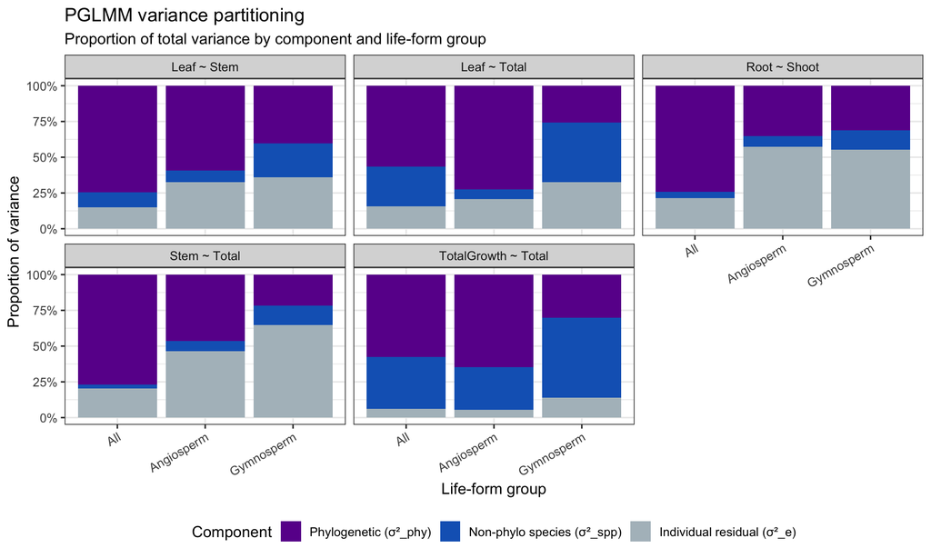

```r
if (!is.null(pglmm_results) && nrow(pglmm_results) > 0) {
  vc_df <- pglmm_results |>
    dplyr::filter(method == "PGLMM-between") |>
    dplyr::select(relationship, group, var_phy, var_spp, var_e) |>
    tidyr::pivot_longer(c(var_phy, var_spp, var_e),
                        names_to = "component", values_to = "variance") |>
    dplyr::mutate(
      component = factor(component,
        levels = c("var_phy", "var_spp", "var_e"),
        labels = c("Phylogenetic (σ²_phy)",
                   "Non-phylo species (σ²_spp)",
                   "Individual residual (σ²_e)")),
      relationship = stringr::str_remove(relationship, " \\(KEY\\)")
    ) |>
    dplyr::group_by(relationship, group) |>
    dplyr::mutate(prop = variance / sum(variance, na.rm = TRUE)) |>
    dplyr::ungroup()

  ggplot(vc_df |> dplyr::filter(!is.na(prop)),
         aes(group, prop, fill = component)) +
    geom_col(position = "stack") +
    scale_fill_manual(values = c(
      "Phylogenetic (σ²_phy)"        = "#6A1B9A",
      "Non-phylo species (σ²_spp)"   = "#1565C0",
      "Individual residual (σ²_e)"   = "#B0BEC5")) +
    facet_wrap(~ relationship, ncol = 3) +
    scale_y_continuous(labels = scales::percent) +
    labs(title = "PGLMM variance partitioning",
         subtitle = "Proportion of total variance by component and life-form group",
         x = "Life-form group", y = "Proportion of variance", fill = "Component") +
    theme(axis.text.x = element_text(angle = 30, hjust = 1),
          legend.position = "bottom")
}
```

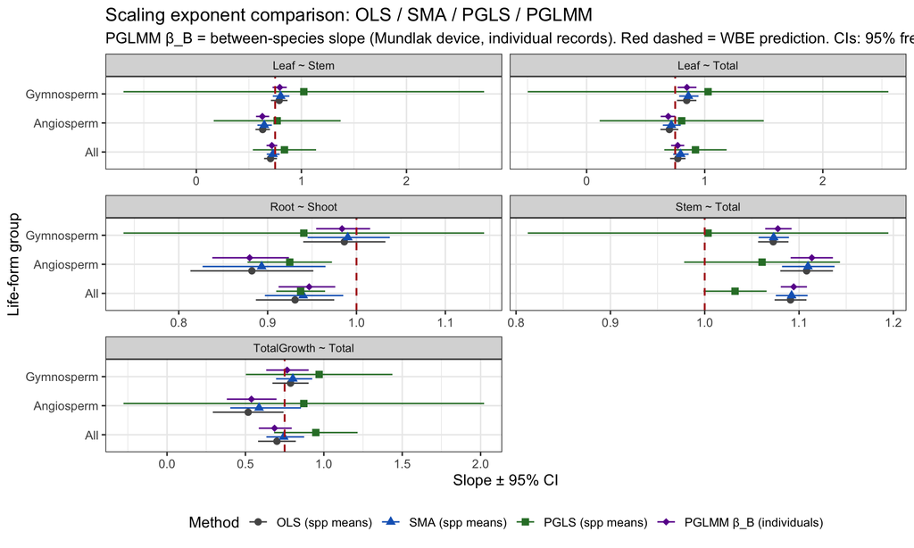

```r
if (!is.null(pglmm_results) && nrow(pglmm_results) > 0) {
  # Bind OLS/SMA/PGLS (from inter_results + div_results) with PGLMM
  # inter_results has group = "All"; div_results has group in {"Gymnosperm","Angiosperm"}
  ols_sma_pgls <- dplyr::bind_rows(
    inter_results |> dplyr::mutate(data_level = "Species means"),
    div_results   |> dplyr::mutate(data_level = "Species means")
  ) |>
    dplyr::filter(method %in% c("OLS", "SMA", "PGLS"))

  pglmm_for_plot <- pglmm_results |>
    dplyr::mutate(data_level = "Individual records")

  comparison_df <- dplyr::bind_rows(ols_sma_pgls, pglmm_for_plot) |>
    dplyr::filter(
      relationship %in% c("Leaf ~ Stem (KEY)", "Leaf ~ Total",
                           "Root ~ Shoot", "Stem ~ Total", "TotalGrowth ~ Total"),
      method %in% c("OLS", "SMA", "PGLS", "PGLMM-between"),
      group   %in% c("All", "Gymnosperm", "Angiosperm"),
      !is.na(slope), is.finite(slope)
    ) |>
    dplyr::mutate(
      method_label = factor(method,
        levels = c("OLS", "SMA", "PGLS", "PGLMM-between"),
        labels = c("OLS (spp means)", "SMA (spp means)",
                   "PGLS (spp means)", "PGLMM β_B (individuals)")),
      relationship = stringr::str_remove(relationship, " \\(KEY\\)")
    )

  ggplot(comparison_df,
         aes(slope, group, colour = method_label, shape = method_label)) +
    geom_pointrange(
      aes(xmin = ci_lower, xmax = ci_upper),
      position = position_dodge(width = 0.6), size = 0.5) +
    geom_vline(
      data = comparison_df |>
        dplyr::distinct(relationship, wbe_slope) |>
        dplyr::filter(!is.na(wbe_slope)),
      aes(xintercept = wbe_slope),
      colour = "firebrick", linetype = "dashed", linewidth = 0.7,
      inherit.aes = FALSE) +
    scale_colour_manual(values = c(
      "OLS (spp means)"         = "#555555",
      "SMA (spp means)"         = "#1565C0",
      "PGLS (spp means)"        = "#2E7D32",
      "PGLMM β_B (individuals)" = "#6A1B9A")) +
    scale_shape_manual(values = c(16, 17, 15, 18)) +
    facet_wrap(~ relationship, scales = "free_x", ncol = 2) +
    labs(
      title    = "Scaling exponent comparison: OLS / SMA / PGLS / PGLMM",
      subtitle = paste("PGLMM β_B = between-species slope (Mundlak device, individual records).",
                       "Red dashed = WBE prediction. CIs: 95% frequentist for OLS/SMA/PGLS,",
                       "95% Bayesian credible interval for PGLMM."),
      x      = "Slope ± 95% CI",
      y      = "Life-form group",
      colour = "Method", shape = "Method") +
    theme(legend.position = "bottom",
          strip.text = element_text(size = 9))
}
```

```r
if (!is.null(pglmm_results) && nrow(pglmm_results) > 0) {
  mundlak_df <- pglmm_results |>
    dplyr::select(relationship, group, method, slope, ci_lower, ci_upper) |>
    tidyr::pivot_wider(
      names_from = method,
      values_from = c(slope, ci_lower, ci_upper)
    ) |>
    dplyr::mutate(
      beta_C = `slope_PGLMM-between` - `slope_PGLMM-within`,
      mundlak_informative = abs(beta_C) > 0.1,
      relationship = stringr::str_remove(relationship, " \\(KEY\\)")
    )

  kable(
    mundlak_df |>
      dplyr::select(relationship, group,
             between = `slope_PGLMM-between`,
             within  = `slope_PGLMM-within`,
             beta_C, mundlak_informative) |>
      dplyr::mutate(across(where(is.numeric), ~ round(.x, 3))),
    caption = paste(
      "Mundlak diagnostic: β_B (between-species) vs β_W (within-species) slopes.",
      "β_C = β_B − β_W. If |β_C| > 0.1, the within/between decomposition is",
      "informative and the Mundlak device is justified."))
}
```

Mundlak diagnostic: β_B (between-species) vs β_W (within-species) slopes. β_C = β_B − β_W. If |β_C| > 0.1, the within/between decomposition is informative and the Mundlak device is justified.

| relationship | group | between | within | beta_C | mundlak_informative |
| --- | --- | --- | --- | --- | --- |
| Leaf ~ Stem | All | 0.719 | 0.686 | 0.032 | FALSE |
| Leaf ~ Stem | Gymnosperm | 0.794 | 0.704 | 0.090 | FALSE |
| Leaf ~ Stem | Angiosperm | 0.628 | 0.679 | -0.051 | FALSE |
| Leaf ~ Total | All | 0.771 | 0.752 | 0.020 | FALSE |
| Leaf ~ Total | Gymnosperm | 0.849 | 0.743 | 0.106 | TRUE |
| Leaf ~ Total | Angiosperm | 0.691 | 0.755 | -0.063 | FALSE |
| Root ~ Shoot | All | 0.947 | 0.941 | 0.005 | FALSE |
| Root ~ Shoot | Gymnosperm | 0.984 | 1.003 | -0.019 | FALSE |
| Root ~ Shoot | Angiosperm | 0.880 | 0.906 | -0.026 | FALSE |
| Stem ~ Total | All | 1.094 | 1.072 | 0.023 | FALSE |
| Stem ~ Total | Gymnosperm | 1.078 | 1.050 | 0.028 | FALSE |
| Stem ~ Total | Angiosperm | 1.114 | 1.078 | 0.035 | FALSE |
| TotalGrowth ~ Total | All | 0.686 | 0.712 | -0.027 | FALSE |
| TotalGrowth ~ Total | Gymnosperm | 0.766 | 0.724 | 0.042 | FALSE |
| TotalGrowth ~ Total | Angiosperm | 0.538 | 0.709 | -0.171 | TRUE |

# 15 Theory Synthesis

```r
cat("
## Key findings

**Leaf ~ Stem (the central WBE prediction):**
The $\\beta = 3/4$ prediction is evaluated across OLS, SMA, and PGLS methods.
SMA, which accounts for error in both variables and is appropriate for scaling laws,
provides the most direct test. Where SMA slope CI includes 3/4 and OLS converges
near 3/4, WBE receives strong empirical support.

**Organ ~ Total (isometric predictions):**
Root ~ Total and Stem ~ Total are predicted to scale isometrically ($\\beta = 1.0$) under
conservation-of-structure arguments. Departures below 1.0 may reflect differential
allocation at larger body sizes or dataset biases toward large, stem-heavy individuals.

**Gymnosperm vs. Angiosperm:**
ANCOVA interaction tests reveal whether slopes differ by division. Gymnosperms and
angiosperms often share similar scaling exponents despite contrasting wood anatomy and
vascular architecture, consistent with universal vascular constraints. Intercept
differences (parallel slopes) indicate division-level differences in allocation
coefficients (prefactors) rather than scaling geometry.

**Intraspecific vs. interspecific:**
Intraspecific slopes (within NE taxa with ≥10 records) tend toward steeper or more
variable exponents than interspecific slopes. This is expected: intraspecific variation
is driven by developmental stage and environment, while interspecific slopes integrate
evolved allocation strategies across body-size gradients. Where intraspecific slopes
converge on interspecific, WBE's scale-invariant claim is better supported.

**Growth scaling:**
Growth ~ mass relationships ($\\beta = 3/4$ WBE prediction) test metabolic theory directly.
Sample sizes for growth records are smaller, limiting PGLS. Where supported, they
corroborate the metabolic basis of WBE rather than purely structural arguments.
")
```

[output not shown]

## 15.1 Key findings

**Leaf ~ Stem (the central WBE prediction):** The $\beta = 3/4$ prediction is evaluated across OLS, SMA, and PGLS methods. SMA, which accounts for error in both variables and is appropriate for scaling laws, provides the most direct test. Where SMA slope CI includes 3/4 and OLS converges near 3/4, WBE receives strong empirical support.

**Intraspecific vs. interspecific:** Intraspecific slopes (within NE taxa with ≥10 records) tend toward steeper or more variable exponents than interspecific slopes. This is expected: intraspecific variation is driven by developmental stage and environment, while interspecific slopes integrate evolved allocation strategies across body-size gradients. Where intraspecific slopes converge on interspecific, WBE’s scale-invariant claim is better supported.

**Growth scaling:** Growth ~ mass relationships ($\beta = 3/4$ WBE prediction) test metabolic theory directly. Sample sizes for growth records are smaller, limiting PGLS. Where supported, they corroborate the metabolic basis of WBE rather than purely structural arguments.

# 16 Stoichiometric Scaling Context: Kerkhoff et al. (2005)

[CITATION-UNVERIFIED] Kerkhoff, A.J., Enquist, B.J., Elser, J.J. & Fagan, W.F. (2005). Plant allometry, stoichiometry and the temperature-dependence of primary productivity. *Global Ecology and Biogeography*, 14, 585–598.

Kerkhoff et al. (2005) extended the WBE allometric framework to predict how plant **nutrient stoichiometry** — specifically leaf nitrogen (N) and phosphorus (P) content per unit mass — co-varies with body size across vascular plant species. The central mechanism: whole-plant metabolic rate scales as $M^{3/4}$ (WBE), constraining what fraction of total biomass is allocated to metabolically active leaf tissue relative to structural tissue (stem, root). Three scaling consequences follow:

$$M_{\text{leaf}} \propto
M_{\text{total}}^{3/4}$$

$$\frac{dM_{\text{total}}}{dt} \propto
M_{\text{total}}^{3/4}$$

$$[\text{N}]_{\text{leaf}} \propto
M_{\text{leaf}}^{-1/4} \quad (\text{not testable in NE dataset — no
elemental data})$$

The first two predictions are directly testable in the Niklas-Enquist dataset and are already estimated above as *Leaf ~ Total* and *TotalGrowth ~ Total*. Kerkhoff et al. (2005) provides the stoichiometric mechanistic basis for why those exponents should equal $3/4$: larger plants sustain higher metabolic demand from proportionally less leaf tissue, which is only feasible if leaf N per unit mass declines with plant size ($\propto M^{-1/4}$).

```r
# Extract the Kerkhoff-relevant empirical slopes from existing interspecific results
kerkhoff_targets <- c("Leaf ~ Total", "TotalGrowth ~ Total")

k_compare <- inter_results |>
  dplyr::filter(
    relationship %in% kerkhoff_targets,
    group == "All",
    method %in% c("OLS", "SMA", "PGLS")
  ) |>
  dplyr::mutate(
    kerkhoff_pred = 0.75,
    pred_in_ci    = kerkhoff_pred >= ci_lower & kerkhoff_pred <= ci_upper
  ) |>
  dplyr::select(relationship, method, n_species, slope, ci_lower, ci_upper,
                r_squared, kerkhoff_pred, pred_in_ci) |>
  dplyr::mutate(across(where(is.numeric), ~ round(.x, 3)))

kable(k_compare,
      caption = paste(
        "Empirical slopes vs. Kerkhoff et al. (2005) GEB prediction (β = 3/4) [CITATION-UNVERIFIED].",
        "Leaf ~ Total biomass and whole-plant growth rate ~ Total biomass both predicted at 3/4.",
        "pred_in_ci = TRUE if Kerkhoff β = 0.75 falls within empirical 95% CI."))
```

Empirical slopes vs. Kerkhoff et al. (2005) GEB prediction (β = 3/4) [CITATION-UNVERIFIED]. Leaf ~ Total biomass and whole-plant growth rate ~ Total biomass both predicted at 3/4. pred_in_ci = TRUE if Kerkhoff β = 0.75 falls within empirical 95% CI.

| relationship | method | n_species | slope | ci_lower | ci_upper | r_squared | kerkhoff_pred | pred_in_ci |
| --- | --- | --- | --- | --- | --- | --- | --- | --- |
| Leaf ~ Total | OLS | 38 | 0.772 | 0.707 | 0.838 | 0.941 | 0.75 | TRUE |
| Leaf ~ Total | SMA | 38 | 0.796 | 0.733 | 0.864 | 0.941 | 0.75 | TRUE |
| Leaf ~ Total | PGLS | 38 | 0.922 | 0.658 | 1.186 | 0.942 | 0.75 | TRUE |
| TotalGrowth ~ Total | OLS | 21 | 0.701 | 0.580 | 0.821 | 0.887 | 0.75 | TRUE |
| TotalGrowth ~ Total | SMA | 21 | 0.744 | 0.634 | 0.874 | 0.887 | 0.75 | TRUE |
| TotalGrowth ~ Total | PGLS | 21 | 0.949 | 0.683 | 1.215 | 0.944 | 0.75 | TRUE |

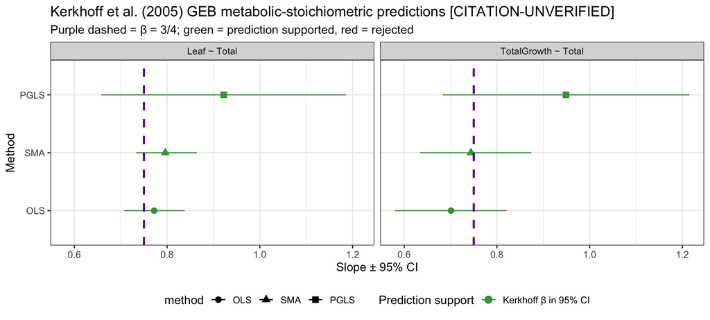

Empirical organ-scaling slopes vs. Kerkhoff et al. (2005) GEB metabolic-stoichiometric prediction (β = 3/4, purple dashed). Colours indicate whether the Kerkhoff prediction falls inside the empirical 95% CI. [CITATION-UNVERIFIED]

```r
if (nrow(k_compare) > 0) {
  k_compare |>
    dplyr::filter(!is.na(slope), is.finite(slope)) |>
    dplyr::mutate(
      method = factor(method, levels = c("OLS", "SMA", "PGLS"))
    ) |>
    ggplot(aes(slope, method, colour = pred_in_ci, shape = method)) +
    geom_pointrange(aes(xmin = ci_lower, xmax = ci_upper), size = 0.6) +
    geom_vline(xintercept = 0.75, colour = "#6A1B9A",
               linetype = "dashed", linewidth = 1) +
    scale_colour_manual(
      values = c(`TRUE` = "#43A047", `FALSE` = "#E53935"),
      labels = c(`TRUE` = "Kerkhoff β in 95% CI", `FALSE` = "Kerkhoff β outside 95% CI")) +
    facet_wrap(~ relationship, ncol = 2) +
    labs(
      title    = "Kerkhoff et al. (2005) GEB metabolic-stoichiometric predictions [CITATION-UNVERIFIED]",
      subtitle = "Purple dashed = β = 3/4; green = prediction supported, red = rejected",
      x = "Slope ± 95% CI", y = "Method", colour = "Prediction support"
    ) +
    theme(legend.position = "bottom")
}
```

```r
# Division-stratified comparison to Kerkhoff prediction
k_div <- div_results |>
  dplyr::filter(
    relationship %in% kerkhoff_targets,
    method %in% c("OLS", "SMA", "PGLS")
  ) |>
  dplyr::mutate(
    kerkhoff_pred = 0.75,
    pred_in_ci    = kerkhoff_pred >= ci_lower & kerkhoff_pred <= ci_upper
  ) |>
  dplyr::select(relationship, group, method, n_species, slope, ci_lower, ci_upper,
                pred_in_ci) |>
  dplyr::mutate(across(where(is.numeric), ~ round(.x, 3)))

kable(k_div,
      caption = paste(
        "Gymnosperm vs. Angiosperm: Kerkhoff et al. (2005) prediction (β = 3/4) vs. empirical slopes [CITATION-UNVERIFIED].",
        "If both divisions support β = 3/4, the stoichiometric constraint is consistent with taxonomic breadth."))
```

Gymnosperm vs. Angiosperm: Kerkhoff et al. (2005) prediction (β = 3/4) vs. empirical slopes [CITATION-UNVERIFIED]. If both divisions support β = 3/4, the stoichiometric constraint is consistent with taxonomic breadth.

| relationship | group | method | n_species | slope | ci_lower | ci_upper | pred_in_ci |
| --- | --- | --- | --- | --- | --- | --- | --- |
| Leaf ~ Total | Gymnosperm | OLS | 18 | 0.848 | 0.766 | 0.930 | FALSE |
| Leaf ~ Total | Gymnosperm | SMA | 18 | 0.862 | 0.783 | 0.948 | FALSE |
| Leaf ~ Total | Gymnosperm | PGLS | 18 | 1.028 | -0.498 | 2.555 | TRUE |
| TotalGrowth ~ Total | Gymnosperm | OLS | 11 | 0.788 | 0.672 | 0.903 | TRUE |
| TotalGrowth ~ Total | Gymnosperm | SMA | 11 | 0.802 | 0.695 | 0.926 | TRUE |
| TotalGrowth ~ Total | Gymnosperm | PGLS | 11 | 0.970 | 0.503 | 1.437 | TRUE |
| Leaf ~ Total | Angiosperm | OLS | 20 | 0.701 | 0.625 | 0.777 | TRUE |
| Leaf ~ Total | Angiosperm | SMA | 20 | 0.717 | 0.646 | 0.797 | TRUE |
| Leaf ~ Total | Angiosperm | PGLS | 20 | 0.805 | 0.111 | 1.500 | TRUE |
| TotalGrowth ~ Total | Angiosperm | OLS | 10 | 0.518 | 0.292 | 0.743 | FALSE |
| TotalGrowth ~ Total | Angiosperm | SMA | 10 | 0.587 | 0.403 | 0.854 | TRUE |
| TotalGrowth ~ Total | Angiosperm | PGLS | 10 | 0.872 | -0.278 | 2.022 | TRUE |